# Tutorial - vtamR pipeline - v1.1.0

2026-08-19

# Summary

**vtamR** is an advanced, R-based revision of VTAM (Validation and Taxonomic Assignment of Metabarcoding Data). It provides a **comprehensive metabarcoding pipeline**, enabling:

- **End-to-End Sequence Analysis:** Processes raw FASTQ files of amplicon sequences to generate a validated [Amplicon Sequence Variant (ASV)](https://people.imbe.fr/~emeglecz/vtamR/tutorial-vtamr-pipeline.html#glossary) table, with ASVs assigned to taxonomic groups.
- **Replicate Handling:** Supports technical or biological replicates of the same sample.
- **Control-Based Filtering:** Uses positive and negative control samples to refine filtering, minimizing both [false positives](https://people.imbe.fr/~emeglecz/vtamR/tutorial-vtamr-pipeline.html#glossary) and [false negatives](https://people.imbe.fr/~emeglecz/vtamR/tutorial-vtamr-pipeline.html#glossary).
- **Data Pooling:** Allows integration of **multiple datasets** (from previous analyses) and results from **overlapping markers**.

**Novelties Compared to VTAM**

- **Modular Design:** As a series of R functions, `vtamR` is **highly adaptable**, allowing users to include, exclude, or reorder analysis steps as needed.
- **Denoising with SWARM:** Incorporates SWARM for robust denoising of amplicon sequence variants (ASVs).
- **Post-Processing of Swarms:** Splits swarms among abundant ASVs to prevent pooling of highly similar yet distinct ASVs, preserving **intra-specific variability**.
- **Visualization Tools:** Offers **graphic options** to aid in data interpretation and decision-making.
- **Filtering Statistics:** Includes functions to generate **statistics for each filtering step** (e.g., read and variant counts).
- **ASV Clustering to mOTU:**
  - Uses **VSEARCH or SWARM** to cluster ASVs into molecular operational taxonomic units (mOTUs).
  - Provides visualization tools to help users **select optimal clustering parameters**.
- **Simplified Workflow:** The concepts of “marker” and “run” have been removed to streamline analyses.

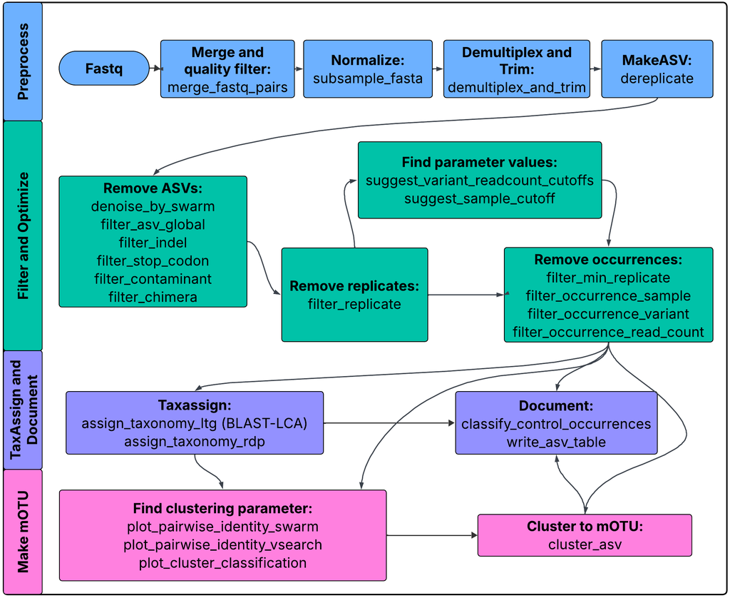

vtamR Workflow

# Installation

Please, follow the Installation instructions.

# Tutorial

This a detailed, tutorial. For impatient users, see the Short tutorial.

## Set up

### Load Library

```r
library(vtamR)
```

### Set Path to Third-Party Programs

If the third-party programs are **not** in your `PATH` (see Installation), **adjust the `xxx_path` variables** according to your setup.

```r
# Example for Windows
cutadapt_path <- "C:/Users/Public/cutadapt"
vsearch_path <- "C:/Users/Public/vsearch-2.23.0-win-x86_64/bin/vsearch"
blast_path <- "C:/Users/Public/blast-2.16.0+/bin/blastn"
swarm_path <- "C:/Users/Public/swarm-3.1.5-win-x86_64/bin/swarm"
pigz_path <- "C:/Users/Public/pigz-win32/pigz" # optional
```

```r
# Example for Linux
cutadapt_path <- "~/miniconda3/envs/vtam/bin/cutadapt"
vsearch_path <- "~/miniconda3/envs/vtam/bin/vsearch"
blast_path <- "~/miniconda3/envs/vtam/bin/blastn"
swarm_path <- "swarm" # swarm is in the PATH
pigz_path <- "pigz"   # optional; pigz is in the PATH
```

If the third-party programs **are** in your `PATH`, you have two options:

1. *Define the `xxx_path` variables as shown below*, and run the tutorial examples exactly as written.

```r
# All executables are in the PATH
#cutadapt_path <- "cutadapt"
cutadapt_path <- "~/miniconda3/envs/vtam_benchmark/bin/cutadapt"
vsearch_path <- "vsearch"
blast_path <- "blastn"
swarm_path <- "swarm"
pigz_path <- "pigz"
```

2. *Do not define the `xxx_path` arguments at all*, and simply omit them when calling the `vtamR` functions.

For example, run:

```r
read_count_df <- filter_chimera(read_count_df)
```

instead of:

```r
read_count_df <- filter_chimera(
  read_count_df,
  vsearch_path = vsearch_path
  )
```

### Input Data

#### Data Structure and Workflow

**Dataset Composition:**

Sequences are typically derived from **96 samples**, corresponding to a 96-well plate used for PCR amplification.

Each plate includes **negative controls, mock samples, and biological samples**. A single sequencing library is generated per replicate, with each library representing a set of 96 PCR reactions.

While `vtamR` can analyze datasets **without controls or replicates**, its full potential is realized when these features are utilized:

- **Controls** enable rigorous data filtering based on control sample content, reducing false positives and negatives.
- **Replicates** ensure reproducibility and minimize technical variability.

For projects exceeding 96 samples, analyses are conducted **plate by plate**.

- Consistent use of control samples ensures **comparability** across different libraries or time points (e.g., longitudinal studies tracking the same sites over time).
- Filtered datasets can be **pooled** using the `pool_dataset()` function for integrated analysis.

**Multi-Marker Analysis**

`vtamR` supports the analysis of the same samples using **multiple, strongly overlapping markers**. For example, our dataset originates from a project [Corse et al., 2017](https://onlinelibrary.wiley.com/doi/10.1111/1755-0998.12703) utilizing two markers: **MFZR** and **ZFZR**.

Both markers target overlapping regions of the **COI gene**, where **MFZR** starts **18 nucleotides upstream** of **ZFZR**.

#### Demo Dataset

The demo files provided in the `vtamR` package include:

- **2 real samples**
- **1 mock sample**
- **1 negative control**

for each **marker-plate combination**. Due to the limited sample size, numerical values and graphs may not be highly informative.

Results from different **marker-plate combinations** are stored in **separate directories**, each maintaining the same structure and filenames. These data sets are processed independently using the same pipeline.

We will first analyze the **first “plate” of the MFZR marker**, then demonstrate how to **pool results** from different plates and markers.

Let’s begin by setting the **output directory** for **plate 1 of MFZR**.

```r
outdir <- file.path("vtamR_demo_out", "mfzr_plate1")
```

**Loading Data**

To load the **demo files included in `vtamR`**, we will use the `system.file()` function. For your own datasets, specify the file and directory paths (e.g., `~/vtamR/fastq`).

```r
fastq_dir <- system.file("extdata/demo/fastq", package = "vtamR")
fastqinfo <-  system.file("extdata/demo/fastqinfo_mfzr_plate1.csv", package = "vtamR")
mock_ncbi_fasta <- system.file("extdata/demo/mock_ncbi.fasta", package = "vtamR")
asv_list <-  system.file("extdata/demo/asv_list.csv", package = "vtamR")
```

- **`fastq_dir`:** Directory containing the input FASTQ files.
- **`fastqinfo`:** CSV file with metadata for input files, including primers, tags, and sample information.
- **`mock_ncbi_fasta`:** FASTA file containing COI sequences of species present in the mock samples.
  - *Note:* These sequences may not be trimmed to the marker region and can slightly differ from the ASVs in the mock samples.
  - *Purpose:* Used to identify which ASVs correspond to expected species in the mock, facilitating the creation of a `mock_composition` file that defines the expected content of mock samples.
- **`asv_list`:** *(Optional)* CSV file containing ASVs and `asv_id`s from previous data sets.

#### Database for Taxonomic Assignment

To perform taxonomic assignment, set the path to:

- The **database** for taxonomic assignment (`blast_db`).
- The **accompanying taxonomy file** (`taxonomy`).

For this example, we use a **small demo database** included in the `vtamR` package.

To obtain a **full reference database** (for real data), visit the TaxAssign Reference Database section.

When using your own data, provide the file names directly, **without** using the `system.file()` function.

```r
taxonomy <- system.file("extdata/db_test/taxonomy_reduced.tsv", package = "vtamR")
blast_db <- system.file("extdata/db_test", package = "vtamR")
blast_db <- file.path(blast_db, "COInr_reduced")
```

### Check the Format of Input Files

The `check_file_info()` function:

- Verifies that all **required columns** are present in your input files.
- Performs **sanity checks** to detect potential errors.

It is optional, but useful, as user-generated files may contain subtle errors that are difficult to identify manually.

```r
check_file_info(file=fastqinfo, dir=fastq_dir, file_type="fastqinfo")
```

```
#> [1] "Sample names are alphanumerical : OK"
#> [1] "Only IUPAC characters in tag_fw: OK"
#> [1] "Only IUPAC characters in tag_rv: OK"
#> [1] "Only IUPAC characters in primer_fw: OK"
#> [1] "Only IUPAC characters in primer_rv: OK"
#> [1] "Coherence between samples and sample_type: OK"
#> [1] "Coherence between samples and habitat: OK"
#> [1] "sample_type: OK"
#> [1] "Coherence between samples and replicates: OK"
#> [1] "File extension: OK"
#> [1] "Coherence between fw and rv fastq filename: OK"
#> [1] "Unique tag combinations : OK"
```

```r
check_file_info(file=asv_list, file_type="asv_list")
```

```
#> [1] "Only IUPAC characters in ASV: OK"
#> [1] "1 to 1 relation between asv_id and asv : OK"
```

> **Before beginning your analysis, review the Tips – Good to Know section.** This section highlights key features and options of `vtamR`, helping you run the functions more effectively.

## Set the log file

vtamR can generate a log file that records every major function called during an analysis. For each function, the log includes:

- all arguments and their values, including default values that were not explicitly specified;
- the start and end times of the function call; and
- the function runtime.

This log is extremely valuable for ensuring reproducibility. It allows you to reconstruct exactly how an analysis was performed, even years later, even if the original script has been lost or modified. The log therefore serves as a complete record of the analysis workflow.

First, define the path to the log file:

```r
log_file <- file.path(outdir, "vtamR_log_mfzr.csv")
```

Whenever the `log_file` argument is provided when calling a vtamR function, the details of that function call are appended to the log file.

Using a log file comes with only two minor requirements, which are well worth the benefit of fully reproducible analyses:

- Specify the `log_file` argument in every major vtamR function call.
- Explicitly name every argument when calling a function (for example, use `my_function(input = my_file)` rather than relying on positional arguments (`my_function(my_file)`).

## Pre-process reads

Your FASTQ files can vary depending on your lab and sequencing setup. They might include:

- **Multiple sample replicates**
- **Tags** (for demultiplexing)
- **Primer sequences**

In this tutorial, our FASTQ files contain reads from several samples. So, we’ll need to:

- **Merge and quality-check** the read pairs using `merge_fastq_pairs`.
- **Subsample** each library to ensure all replicates have similar coverage with `subsample_fasta`.
- **Demultiplex** and trim off tags and primers with `demultiplex_and_trim_fasta`.

See the From fastq to data frame on how to deal with other experimental designs.

### Merge Fastq Pairs and Quality Filter

The `merge_fastq_pairs` function combines each read-pair into a single sequence in fasta format and can also handle **quality filtering**.

- **`compress = FALSE`:** In this tutorial, we’ll work with uncompressed files. For guidance on whether to compress your files, check out the To Compress or Not to Compress section.
- **Managing Large Files:** Once your analysis is complete, you might want to compress or delete large intermediate files. For tips on this, see Files to Keep.
- **More Options:** For additional quality filtering options, take a look at `?merge_fastq_pairs`.

**Key Files**

- **fastqinfo:** This can be either a CSV file or a data frame.
- **fastainfo_df:** This is the output of `merge_fastq_pairs`. It’s an updated version of `fastqinfo`, where FASTQ filenames are replaced with FASTA filenames, and read counts are included for each file.

```r
merged_dir <- file.path(outdir, "1_merged")

fastainfo_df <- merge_fastq_pairs(
  fastqinfo=fastqinfo,
  fastq_dir=fastq_dir, # directory of input fasta files
  vsearch_path=vsearch_path, # can be omitted if VSEARCH is in the PATH
  outdir=merged_dir, # directory of output fasta files
  fastq_maxee=1, # Maximum Expected Error for each read
  fastq_maxns=0, # no Ns in output
  compress=FALSE,
  fastq_allowmergestagger=T, # reads might be longer than the marker
  log_file = log_file
  )
```

### Randomly Select Sequences (Subsampling)

The `subsample_fasta` function lets you randomly pick `n` sequences (without replacement) from each FASTA file listed in your `fastainfo` data frame.

This step is great for **balancing read counts across your sequencing libraries**. It’s optional, but can be really helpful if you want to make sure all your replicates have a similar number of reads.

**Two ways to do random sampling**

- Using VSEARCH (`use_vsearch = TRUE`):
  - **Fast**, but only works on **Linux-like** systems.
- Using R Only (`use_vsearch = FALSE`):
  - **Slower**, but works on **all operating systems**.

I’m using the **slower but cross-platform** R-only version. For more details, check out the `subsample_fasta` documentation.

```r
randomseq_dir <- file.path(outdir, "2_random_seq")

fastainfo_df <- subsample_fasta(
  fastainfo = fastainfo_df, # input df (output of merge_fastq_pairs)
  fasta_dir = merged_dir, # directory of input fasta files.
  outdir = randomseq_dir,  # directory of output fasta files.
  use_vsearch  = FALSE, # use cross-platform version
  n = 40000, # select n sequences from each file
  randseed=123, #  A given non-zero seed produces always the same result.
  log_file = log_file
  )
```

```
#> Warning: WARNING: vtamR_demo_out/mfzr_plate1/1_merged/mfzr_1_fw.fasta contains 37351 sequences.
#> The input file is copied to output.
```

You may encounter a **warning** indicating that the file `mfzr_1_fw.fasta` contains fewer than 40,000 sequences. Since subsampling is performed **without replacement**, this file will be copied directly to the output directory. As a result, it will contain slightly fewer reads than the other files — this is expected and not a cause for concern.

### Demultiplex and Trim

The `demultiplex_and_trim_fasta` function is used to both **demultiplex** your FASTA files (i.e. separate reads based on their tag combinations) and **trim** tag and primer sequences from those reads.

You can check the help page (`?demultiplex_and_trim_fasta`) to choose the right settings for your data.

- If `check_reverse = TRUE`, the function will also look for matches on the reverse complement strand.
- `sampleinfo_df` is an updated version of `fastainfo_df`.
- This data frame, along with the files it references, is used as input for the `dereplicate` step.

```r
demultiplexed_dir <- file.path(outdir, "3_demultiplexed")

sampleinfo_df <- demultiplex_and_trim_fasta(
  fastainfo=fastainfo_df,  # input df (output of subsample_fasta)
  fasta_dir=randomseq_dir, # input directory with fasta files
  outdir=demultiplexed_dir,  # output directory
  check_reverse=TRUE,
  cutadapt_path=cutadapt_path, # can be omitted if CUTADAPT is in the PATH
  vsearch_path=vsearch_path, # can be omitted if VSEARCH is in the PATH
  cutadapt_minimum_length = 170,
  cutadapt_maximum_length = 185,
  log_file = log_file
  )
```

### Dereplicate

At this stage, you should have **one FASTA file per sample-replicate**, containing merged reads with tags and primers already removed.

The next step is to **dereplicate** these files. This means grouping identical sequences together so that each unique sequence (an ASV) is assigned a unique numerical ID (an asv_id).

**Output**

The output is a data frame called read_count_df, which can also be saved as a **CSV file** if you provide the `outfile` argument. Saving this file is strongly recommended—it becomes your starting point for filtering. This way, you can try different filtering strategies without having to re-run the more time-consuming pre-processing steps.

**ASV Identifiers**

If you want to keep **ASV IDs consistent with a previous analysis**, you can provide a reference file (asv_list) containing existing ASVs and their IDs. The updated and complete list of ASVs will then be written to `output_asv_list`.

If you only provide `output_asv_list` (without an `input_asv_list`), the function will simply write out the full list of current ASVs with their assigned IDs. This is useful if you plan to analyze additional datasets later and want to keep ASV IDs consistent across studies.

```r
outfile <- file.path(outdir, "4_filter", "1_before_filter.csv")
updated_asv_list <- file.path(outdir, "ASV_list_with_IDs.csv")

read_count_df <- dereplicate(
  sampleinfo=sampleinfo_df, # input df (output of demultiplex_and_trim_fasta)
  dir=demultiplexed_dir, # directory with input fasta files
  outfile=outfile, # write the output data frame to this file
  input_asv_list=asv_list,
  output_asv_list=updated_asv_list,
  log_file = log_file
  )
```

## Filtering

`vtamR` provides many functions to **filter out ASVs** or **ASV occurrences** within a sample-replicate that may result from **technical or biological issues in metabarcoding**.

There are two main ways to apply these filters:

- You can **apply them independently to the original dataset** and then combine the results using the `pool_filters` function. In this case, only occurrences that pass *all* filters are kept.
- Or you can **apply them sequentially**, one after the other, in any order that fits your analysis.

In this section, I’ll show an example that uses several filtering options. However, you are encouraged to **build your own pipeline** based on your specific needs.

**Output data frame and CSV**

Each filtering function returns a **data frame with the filtered results**. You can also save the output as a **CSV file** using the `outfile` argument. This is especially useful if you want to track how ASVs or samples are retained or removed throughout the analysis, using the history_by and summarize_by functions.

To keep things organized, I recommend **starting output file names with a number** to reflect the order of the steps. This also allows the summarize_by function to easily generate summary statistics at each stage of the analysis.

### Tracking the Evolution of Reads and ASVs (`stat_df`)

You can **monitor changes in the number of reads and ASVs** after each filtering step using the `get_stat` function. This function either:

- Creates a new data frame with read and ASV counts, or
- Appends a new row to an existing data frame provided as an argument (`stat_df`).

The resulting data frame contains the following columns:

- `parameters`: Parameters used for the analysis
- `asv_count`: Number of ASVs detected
- `read_count`: Total number of reads
- `sample_count`: Number of samples analyzed
- `sample_replicate_count`: Number of replicates per sample

Each row summarizes the results of a single filtering step. By calling `get_stat` after each step, you can incrementally build a data frame with **key summary statistics** for every stage of your analysis.

**The main arguments**

- **`params`**: A string describing the key parameters applied during the filtering step.
- **`stage`**: A string indicating the analysis stage (e.g., “input”, “denoising”, “filtering”) to which the statistics correspond.

```r
stat_df <- get_stat(read_count_df, stat_df = NULL, stage = "input", params = NA)
```

Let’s check number od reads, ASV, samples in the initial non-filtereg dataset.

```r
knitr::kable(stat_df, format = "markdown")
```

|  | parameters | asv_count | read_count | sample_count | sample_replicate_count |
| --- | --- | --- | --- | --- | --- |
| input | NA | 10013 | 116447 | 4 | 12 |

### Denoising with SWARM

In metabarcoding datasets, sequencing errors often produce many low-frequency ASVs that do not reflect real biological sequences. A common way to reduce this noise is to use **SWARM** (Mahé et al., 2015), a fast and widely used algorithm that groups highly similar ASVs together.

**Running SWARM in `vtamR`**

You can run SWARM directly with the `denoise_by_swarm()` function.

Since the goal here is **denoising** (and not clustering into mOTUs), the recommended settings are:

- `swarm_d = 1`: allows only one difference between ASVs
- `fastidious = TRUE`: adds a second pass to refine clusters and reduce small ones

These settings are designed to remove sequencing errors while preserving real biological variation.

#### Whole Dataset vs. Sample-by-Sample Clustering**

There are two ways to apply SWARM:

- `by_sample = FALSE` (default): SWARM is applied to the entire data set. This approach is more aggressive and efficiently reduces the total number of ASVs.
- `by_sample = TRUE`: SWARM is applied separately to each sample. This is more conservative and helps preserve biological variation.

If you are interested in **intra-specific variation**, it is generally better to use `by_sample = TRUE`, as very similar but real ASVs in different samples might otherwise be merged.

#### Refining Clusters With `split_clusters`

Even with `d = 1` and `fastidious = TRUE`, SWARM may still group ASVs that differ by only one nucleotide but have **similar read abundances**. This can lead to real biological variants being merged into a single cluster.

To address this, `denoise_by_swarm()` includes an optional post-processing step with `split_clusters = TRUE`. This step attempts to recover meaningful variants that may have been incorrectly merged.

For each cluster:

- ASVs are evaluated based on two criteria:
  - their read count relative to the cluster centroid (`min_abundance_ratio`)
  - a minimum absolute read count (`min_read_count`)
- ASVs that meet both criteria are considered biologically meaningful, and **each forms a new cluster**
- The total reads from the original cluster are then redistributed among these ASVs, while keeping their original proportions.
- If no ASV meets the criteria, the cluster remains unchanged (all reads are pooled together).

The `split_clusters` option should be used with the following settings:

- `by_sample = TRUE`
- `swarm_d = 1` (default)
- `fastidious = TRUE` (default)

```r
split_clusters <- TRUE
by_sample <- TRUE

outfile <- file.path(outdir, "4_filter", "2_swarm_denoise.csv")
read_count_df <- denoise_by_swarm(
  read_count = read_count_df,
  outfile=outfile,
  by_sample=by_sample,
  split_clusters=split_clusters,
  swarm_path=swarm_path,
  quiet=TRUE,
  log_file = log_file
  )

param <- paste("by_sample:", by_sample, "split_clusters:", split_clusters, sep=" ")
stat_df <- get_stat(read_count_df, stat_df, stage="swarm_denoise", params=param)
```

Let’s check the reduction of the number of variants after running `swarm`.

```r
knitr::kable(stat_df, format = "markdown")
```

|  | parameters | asv_count | read_count | sample_count | sample_replicate_count |
| --- | --- | --- | --- | --- | --- |
| input | NA | 10013 | 116447 | 4 | 12 |
| swarm_denoise | by_sample: TRUE split_clusters: TRUE | 1112 | 116446 | 4 | 12 |

The small variation in the total number of reads comes from rounding when redistributing reads among clusters that have been split.

### Filter out ASVs with Low Total Read Count (`filter_asv_global`)

Although SWARM has already reduced the number of ASVs considerably, many ASVs with low read counts may still remain.

The `filter_asv_global` function removes all ASVs whose **total read count** is below a chosen threshold.

Here, we will eliminate singletons and observe how the **number of ASVs and total reads** changes after this step.

```r
global_read_count_cutoff = 2
outfile <- file.path(outdir, "4_filter", "3_filter_asv_global.csv")

read_count_df <- filter_asv_global(
  read_count = read_count_df,
  outfile=outfile,
  cutoff=global_read_count_cutoff,
  log_file = log_file
  )

param <- paste("global_read_count_cutoff:", global_read_count_cutoff, sep=" ")
stat_df <- get_stat(read_count_df, stat_df, stage="filter_asv_global", params=param)


knitr::kable(stat_df, format = "markdown")
```

|  | parameters | asv_count | read_count | sample_count | sample_replicate_count |
| --- | --- | --- | --- | --- | --- |
| input | NA | 10013 | 116447 | 4 | 12 |
| swarm_denoise | by_sample: TRUE split_clusters: TRUE | 1112 | 116446 | 4 | 12 |
| filter_asv_global | global_read_count_cutoff: 2 | 204 | 115538 | 4 | 12 |

### Filter ASVs Based on Read Length (`filter_indel`)

This filter is **only applicable to coding sequences**.

The idea is simple: if the length of an ASV differs from the most common ASV length by a value that is **not a multiple of 3**, it is likely to be an erroneous sequence or a pseudogene.

```r
outfile <- file.path(outdir, "4_filter", "4_filter_indel.csv")

read_count_df <- filter_indel(
  read_count = read_count_df,
  outfile=outfile,
  log_file = log_file
  )

stat_df <- get_stat(read_count_df, stat_df, stage="filter_indel", params=NA)

knitr::kable(stat_df, format = "markdown")
```

|  | parameters | asv_count | read_count | sample_count | sample_replicate_count |
| --- | --- | --- | --- | --- | --- |
| input | NA | 10013 | 116447 | 4 | 12 |
| swarm_denoise | by_sample: TRUE split_clusters: TRUE | 1112 | 116446 | 4 | 12 |
| filter_asv_global | global_read_count_cutoff: 2 | 204 | 115538 | 4 | 12 |
| filter_indel | NA | 191 | 115364 | 4 | 12 |

### Filter ASVs with Stop Codons (`filter_stop_codon`)

This filter is **only applicable to coding sequences**.

It checks for the presence of **STOP codons** in all three possible reading frames and removes ASVs that contain STOP codons in each of them.

You can specify the genetic code using its numerical ID from [NCBI](https://www.ncbi.nlm.nih.gov/Taxonomy/Utils/wprintgc.cgi?chapter=cgencodes). By default, the function uses the **invertebrate mitochondrial genetic code (code 5)**, as its STOP codons are also valid STOP codons in most other genetic codes.

```r
outfile <- file.path(outdir, "4_filter", "5_filter_stop_codon.csv")

genetic_code = 5
read_count_df <- filter_stop_codon(
  read_count = read_count_df,
  genetic_code=genetic_code,
  outfile=outfile,
  log_file = log_file
  )

param <- paste("genetic_code:", genetic_code, sep=" ")
stat_df <- get_stat(read_count_df, stat_df, stage="filter_stop_codon", params=param)

knitr::kable(stat_df, format = "markdown")
```

|  | parameters | asv_count | read_count | sample_count | sample_replicate_count |
| --- | --- | --- | --- | --- | --- |
| input | NA | 10013 | 116447 | 4 | 12 |
| swarm_denoise | by_sample: TRUE split_clusters: TRUE | 1112 | 116446 | 4 | 12 |
| filter_asv_global | global_read_count_cutoff: 2 | 204 | 115538 | 4 | 12 |
| filter_indel | NA | 191 | 115364 | 4 | 12 |
| filter_stop_codon | genetic_code: 5 | 191 | 115364 | 4 | 12 |

### Filter Potential Contaminant ASVs (`filter_contaminant`)

This filter detects ASVs whose **read counts are higher in at least one negative control** than in any real sample. These ASVs are considered potential contaminants and are removed from the dataset.

The `conta_file` records the data for the ASVs that were removed. It’s a good idea to **check this file** to make sure nothing unusual is happening.

```r
outfile <- file.path(outdir, "4_filter", "6_filter_contaminant.csv")
conta_file <- file.path(outdir, "4_filter", "potential_contaminants.csv")

read_count_df <- filter_contaminant(
  read_count = read_count_df,
  sampleinfo=sampleinfo_df,
  conta_file=conta_file,
  outfile=outfile,
  log_file = log_file
  )

stat_df <- get_stat(read_count_df, stat_df, stage="filter_contaminant", params=NA)

knitr::kable(stat_df, format = "markdown")
```

|  | parameters | asv_count | read_count | sample_count | sample_replicate_count |
| --- | --- | --- | --- | --- | --- |
| input | NA | 10013 | 116447 | 4 | 12 |
| swarm_denoise | by_sample: TRUE split_clusters: TRUE | 1112 | 116446 | 4 | 12 |
| filter_asv_global | global_read_count_cutoff: 2 | 204 | 115538 | 4 | 12 |
| filter_indel | NA | 191 | 115364 | 4 | 12 |
| filter_stop_codon | genetic_code: 5 | 191 | 115364 | 4 | 12 |
| filter_contaminant | NA | 175 | 115249 | 4 | 12 |

### Filter Chimeric ASVs (`filter_chimera`)

This function uses the `uchime3_denovo` algorithm implemented in **VSEARCH** to detect chimeras.

- If `by_sample = FALSE` (default), ASVs identified as chimeras across the **whole dataset** are removed.
- If `by_sample = TRUE`, an ASV is removed only if it is detected as a chimera in at least a proportion of samples defined by `sample_prop`.

The `abskew` parameter sets the **minimum frequency difference**: a chimera must be at least `abskew` times less abundant than its parental ASVs to be flagged.

```r
outfile <- file.path(outdir, "4_filter", "7_filter_chimera.csv")
abskew=2
by_sample = TRUE
sample_prop = 0.8

read_count_df <- filter_chimera(
  read_count = read_count_df,
  vsearch_path=vsearch_path,
  outfile=outfile,
  by_sample=by_sample,
  sample_prop=sample_prop,
  abskew=abskew,
  log_file = log_file
  )

param <- paste("by_sample:", by_sample, "sample_prop:", sample_prop, "abskew:", abskew, sep=" ")
stat_df <- get_stat(read_count_df, stat_df, stage="filter_chimera", params=param)

knitr::kable(stat_df, format = "markdown")
```

|  | parameters | asv_count | read_count | sample_count | sample_replicate_count |
| --- | --- | --- | --- | --- | --- |
| input | NA | 10013 | 116447 | 4 | 12 |
| swarm_denoise | by_sample: TRUE split_clusters: TRUE | 1112 | 116446 | 4 | 12 |
| filter_asv_global | global_read_count_cutoff: 2 | 204 | 115538 | 4 | 12 |
| filter_indel | NA | 191 | 115364 | 4 | 12 |
| filter_stop_codon | genetic_code: 5 | 191 | 115364 | 4 | 12 |
| filter_contaminant | NA | 175 | 115249 | 4 | 12 |
| filter_chimera | by_sample: TRUE sample_prop: 0.8 abskew: 2 | 141 | 114682 | 4 | 12 |

### Filter Aberrant Replicates (`filter_replicate`)

This filter removes **replicates that are very different** from other replicates of the same sample.

To do this, we calculate the Renkonen distances between all pairs of replicates within each sample and identify those that deviate significantly from the others.

```r
renkonen_within_df <- compute_renkonen_distances(
  read_count = read_count_df,
  compare_all=FALSE,
  log_file = log_file)
```

#### Visualize Renkonen Distances

We can create a **density plot** of the Renkonen distances to see how similar replicates are within each sample.

**Note:** This example uses a very small test dataset, so your own data will likely produce a **different-looking graph**.

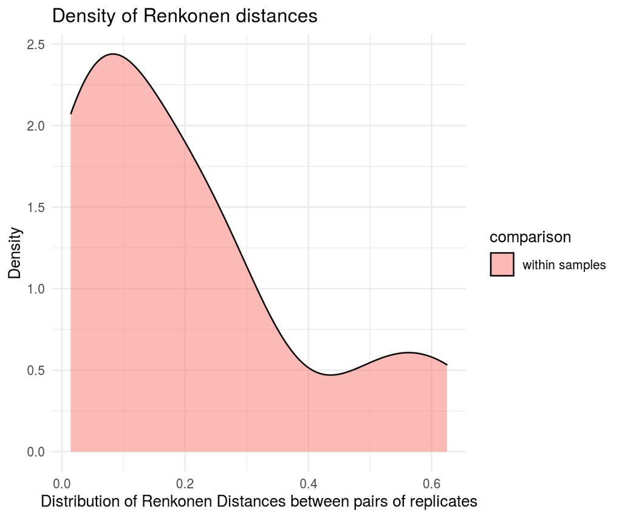

```r
plot_renkonen_distance_density(
  df = renkonen_within_df,
  log_file = log_file)
```

We can also create a **barplot of the Renkonen distances**, using different colors to represent **sample types** (real, mock, or negative).

**Notes:**

- `sampleinfo_df` must have `sample` and `sample_type` columns, but any data frame with these columns will work.
- If `sampleinfo_df` is not in your environment, you can use the **sampleinfo.csv** instead of the data frame. This files was produced by `demultiplex_and_trim_fasta` in this pipeline and found in the **vtamR_demo_out/mfzr_plate1/3_demultiplexed** folder.
- This is a **very small test data set**, so your own data will likely produce a **different-looking graph**.

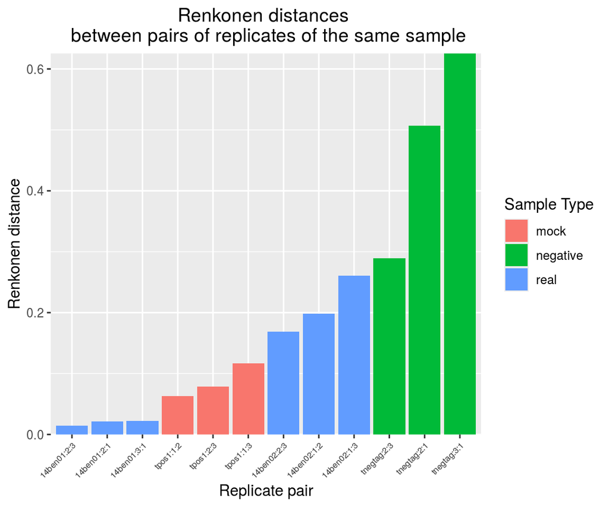

```r
plot_renkonen_distance_barplot(
  df = renkonen_within_df,
  sampleinfo=sampleinfo_df,
  x_axis_label_size=6,
  log_file = log_file
  )
```

#### Determine Cutoff for Replicate Filtering

In this example, there are only a few Renkonen distance values, so the **density plot** isn’t very informative. The **barplot**, however, shows that **replicate 1 of the `tnegtag` sample** (a negative control) is substantially different from the other two replicates. Setting `cutoff = 0.4` would be a reasonable choice for the `filter_replicate` function.

The `filter_replicate` function removes replicates whose **Renkonen distances exceed the cutoff** relative to most other replicates of the same sample. Here, this means that **replicate 1 of `tnegtag` will be removed**.

An **alternative way to define the cutoff** is to use the `renkonen_distance_quantile` parameter instead of a fixed `cutoff`. This automatically sets the cutoff based on a chosen **quantile of the within-sample distance distribution**. For example:

- `renkonen_distance_quantile = 0.9` sets the cutoff at the **90th percentile** of distances, i.e., between the 9th and 10th decile.

In this tutorial, we will **use the quantile-based option** to determine the cutoff.

```r
outfile <- file.path(outdir, "4_filter", "8_filter_replicate.csv")
renkonen_distance_quantile <- 0.9

read_count_df <- filter_replicate(
  read_count = read_count_df,
  outfile = outfile,
  renkonen_distance_quantile = renkonen_distance_quantile,
  log_file = log_file
  )
```

```
#> [1] "The cutoff value for Renkonen distances is  0.289308176100629"
```

```r
param <- paste("renkonen_distance_quantile:", renkonen_distance_quantile, sep=" ")
stat_df <- get_stat(read_count_df, stat_df, stage="filter_replicate", params=param)

knitr::kable(stat_df, format = "markdown")
```

|  | parameters | asv_count | read_count | sample_count | sample_replicate_count |
| --- | --- | --- | --- | --- | --- |
| input | NA | 10013 | 116447 | 4 | 12 |
| swarm_denoise | by_sample: TRUE split_clusters: TRUE | 1112 | 116446 | 4 | 12 |
| filter_asv_global | global_read_count_cutoff: 2 | 204 | 115538 | 4 | 12 |
| filter_indel | NA | 191 | 115364 | 4 | 12 |
| filter_stop_codon | genetic_code: 5 | 191 | 115364 | 4 | 12 |
| filter_contaminant | NA | 175 | 115249 | 4 | 12 |
| filter_chimera | by_sample: TRUE sample_prop: 0.8 abskew: 2 | 141 | 114682 | 4 | 12 |
| filter_replicate | renkonen_distance_quantile: 0.9 | 141 | 114655 | 4 | 11 |

You can use the `renkonen_distance_quantile` argument if the density plot is difficult to interpret or if you prefer to automate the pipeline and avoid manually selecting the `cutoff` for the `filter_replicate` function.

### Create `mock_composition` File

The mock_composition file is needed to **suggest parameter values** for some filtering steps. It should list the **expected ASVs** in each mock sample.

If you don’t know the exact sequences of the species in your mock samples, see How to make a mock_composition file for guidance.

Here’s a quick example of how to create it. After generating the file, check **`mock_composition_template_to_check.csv`** to make sure **all ASVs have been correctly identified**.

```r
outdir_mock <- file.path(outdir, "mock_composition")

mock_template <- match_variants_to_mock_species(
  read_count = read_count_df,
  fas=mock_ncbi_fasta, # fasta with reference sequences on the mock or closely related species
  taxonomy=taxonomy,
  sampleinfo = sampleinfo_df,
  outdir= outdir_mock,
  blast_path=blast_path,
  log_file = log_file
  )
mock_composition <- file.path(outdir_mock, "mock_composition_template_to_check.csv")
mock_composition_df <- read.csv(mock_composition)
knitr::kable(mock_composition_df, format = "markdown")
```

| sample | action | asv | taxon | asv_id |
| --- | --- | --- | --- | --- |
| tpos1 | keep | TCTATATTTCATTTTTGGTGCTTGGGCAGGTATGGTAGGTACCTCATTAAGACTTTTAATTCGAGCCGAGTTGGGTAACCCGGGTTCATTAATTGGGGACGATCAAATTTATAACGTAATCGTAACTGCTCATGCCTTTATTATGATTTTTTTTATAGTGATACCTATTATAATT | Baetis rhodani | 5 |
| tpos1 | keep | ACTATATTTTATTTTTGGGGCTTGATCCGGAATGCTGGGCACCTCTCTAAGCCTTCTAATTCGTGCCGAGCTGGGGCACCCGGGTTCTTTAATTGGCGACGATCAAATTTACAATGTAATCGTCACAGCCCATGCTTTTATTATGATTTTTTTCATGGTTATGCCTATTATAATC | Caenis pusilla | 1 |
| tpos1 | keep | CCTTTATTTTATTTTCGGTATCTGATCAGGTCTCGTAGGATCATCACTTAGATTTATTATTCGAATAGAATTAAGAACTCCTGGTAGATTTATTGGCAACGACCAAATTTATAACGTAATTGTTACATCTCATGCATTTATTATAATTTTTTTTATAGTTATACCAATCATAATT | Hydropsyche pellucidula | 3 |
| tpos1 | keep | CCTTTATCTTGTATTTGGTGCCTGGGCCGGAATGGTAGGGACCGCCCTAAGCCTTCTTATTCGGGCCGAACTAAGCCAGCCTGGCTCGCTATTAGGTGATAGCCAAATTTATAATGTTATTGTTACCGCCCACGCCTTCGTAATAATTTTCTTTATAGTCATGCCAATTCTCATT | Phoxinus phoxinus | 6 |
| tpos1 | keep | ACTTTATTTTATTTTTGGTGCTTGATCAGGAATAGTAGGAACTTCTTTAAGAATTCTAATTCGAGCTGAATTAGGTCATGCCGGTTCATTAATTGGAGATGATCAAATTTATAATGTAATTGTAACTGCTCATGCTTTTGTAATAATTTTCTTTATAGTTATACCTATTTTAATT | Rheocricotopus chalybeatus | 2 |
| tpos1 | keep | CTTATATTTTATTTTTGGTGCTTGATCAGGGATAGTGGGAACTTCTTTAAGAATTCTTATTCGAGCTGAACTTGGTCATGCGGGATCTTTAATCGGAGACGATCAAATTTACAATGTAATTGTTACTGCACACGCCTTTGTAATAATTTTTTTTATAGTTATACCTATTTTAATT | Synorthocladius semivirens | 4 |

### Filter Low-Abundance Occurrences within Samples (`filter_occurrence_sample`)

The `filter_occurrence_sample` function removes **ASV occurrences with very low read counts** relative to the total reads in a sample-replicate. The default cutoff proportion is **0.001**.

To choose a suitable `cutoff`, you can examine the **proportions of expected ASVs in your mock samples** using the `suggest_sample_cutoff` function. This ensures that **real, low-abundance ASVs** are not accidentally removed by setting the cutoff **below the lowest observed proportion**.

#### Suggest Filter Parameters Based on Mock Sample (`suggest_sample_cutoff`)

**Note:** If you don’t yet know the exact sequences in your mock samples and therefore **don’t have a mock_composition file**, see How to make a mock_composition file for guidance.

```r
outfile = file.path(outdir, "4_filter", "suggest_parameters", "sample_cutoff.csv")

suggest_sample_cutoff_df <- suggest_sample_cutoff(
  read_count = read_count_df,
  mock_composition = mock_composition,
  outfile = outfile,
  log_file = log_file
  )

knitr::kable(head(suggest_sample_cutoff_df), format = "markdown")
```

| sample | replicate | action | asv_id | sample_cutoff | read_count | read_count_sample_replicate | asv | taxon |
| --- | --- | --- | --- | --- | --- | --- | --- | --- |
| tpos1 | 3 | keep | 1 | 0.0048 | 98 | 20374 | ACTATATTTTATTTTTGGGGCTTGATCCGGAATGCTGGGCACCTCTCTAAGCCTTCTAATTCGTGCCGAGCTGGGGCACCCGGGTTCTTTAATTGGCGACGATCAAATTTACAATGTAATCGTCACAGCCCATGCTTTTATTATGATTTTTTTCATGGTTATGCCTATTATAATC | Caenis pusilla |
| tpos1 | 1 | keep | 6 | 0.0085 | 186 | 21848 | CCTTTATCTTGTATTTGGTGCCTGGGCCGGAATGGTAGGGACCGCCCTAAGCCTTCTTATTCGGGCCGAACTAAGCCAGCCTGGCTCGCTATTAGGTGATAGCCAAATTTATAATGTTATTGTTACCGCCCACGCCTTCGTAATAATTTTCTTTATAGTCATGCCAATTCTCATT | Phoxinus phoxinus |
| tpos1 | 2 | keep | 6 | 0.0087 | 239 | 27220 | CCTTTATCTTGTATTTGGTGCCTGGGCCGGAATGGTAGGGACCGCCCTAAGCCTTCTTATTCGGGCCGAACTAAGCCAGCCTGGCTCGCTATTAGGTGATAGCCAAATTTATAATGTTATTGTTACCGCCCACGCCTTCGTAATAATTTTCTTTATAGTCATGCCAATTCTCATT | Phoxinus phoxinus |
| tpos1 | 2 | keep | 1 | 0.0090 | 247 | 27220 | ACTATATTTTATTTTTGGGGCTTGATCCGGAATGCTGGGCACCTCTCTAAGCCTTCTAATTCGTGCCGAGCTGGGGCACCCGGGTTCTTTAATTGGCGACGATCAAATTTACAATGTAATCGTCACAGCCCATGCTTTTATTATGATTTTTTTCATGGTTATGCCTATTATAATC | Caenis pusilla |
| tpos1 | 3 | keep | 6 | 0.0093 | 190 | 20374 | CCTTTATCTTGTATTTGGTGCCTGGGCCGGAATGGTAGGGACCGCCCTAAGCCTTCTTATTCGGGCCGAACTAAGCCAGCCTGGCTCGCTATTAGGTGATAGCCAAATTTATAATGTTATTGTTACCGCCCACGCCTTCGTAATAATTTTCTTTATAGTCATGCCAATTCTCATT | Phoxinus phoxinus |
| tpos1 | 2 | keep | 4 | 0.0119 | 324 | 27220 | CTTATATTTTATTTTTGGTGCTTGATCAGGGATAGTGGGAACTTCTTTAAGAATTCTTATTCGAGCTGAACTTGGTCATGCGGGATCTTTAATCGGAGACGATCAAATTTACAATGTAATTGTTACTGCACACGCCTTTGTAATAATTTTTTTTATAGTTATACCTATTTTAATT | Synorthocladius semivirens |

#### Choose a Cutoff for `filter_occurrence_sample`

The rows in `suggest_sample_cutoff_df` are sorted by the `sample_cutoff` column in **increasing order**.

**Note:**

- If all species in the mock community amplify equally well, the minimum `sample_cutoff` may be relatively high. In such cases, it’s often safer to choose a **low arbitrary value** (e.g., 0.001–0.005).
- The optimal threshold depends on your **environmental sample complexity**: the more taxa you expect, the **lower the cutoff** should be.

In practice, **strong PCR amplification bias is common**, so scenarios where all mock species amplify equally well are rare.

When designing mock communities for a metabarcoding experiment, it’s recommended to include **some species known to amplify poorly**. This requires **pre-testing and optimization**, but ensures that your mock sample realistically reflects amplification biases before analyzing your actual environmental samples.

#### Filter Low-Abundance Occurrences within Samples

```r
sample_cutoff <- 0.004
outfile <- file.path(outdir, "4_filter", "9_filter_occurrence_sample.csv")

read_count_df <- filter_occurrence_sample(
  read_count = read_count_df,
  cutoff=sample_cutoff,
  outfile=outfile,
  log_file = log_file
  )

param <- paste("cutoff:", sample_cutoff, sep=" ")
stat_df <- get_stat(read_count_df, stat_df, stage="filter_occurrence_sample", params=param)

knitr::kable(stat_df, format = "markdown")
```

|  | parameters | asv_count | read_count | sample_count | sample_replicate_count |
| --- | --- | --- | --- | --- | --- |
| input | NA | 10013 | 116447 | 4 | 12 |
| swarm_denoise | by_sample: TRUE split_clusters: TRUE | 1112 | 116446 | 4 | 12 |
| filter_asv_global | global_read_count_cutoff: 2 | 204 | 115538 | 4 | 12 |
| filter_indel | NA | 191 | 115364 | 4 | 12 |
| filter_stop_codon | genetic_code: 5 | 191 | 115364 | 4 | 12 |
| filter_contaminant | NA | 175 | 115249 | 4 | 12 |
| filter_chimera | by_sample: TRUE sample_prop: 0.8 abskew: 2 | 141 | 114682 | 4 | 12 |
| filter_replicate | renkonen_distance_quantile: 0.9 | 141 | 114655 | 4 | 11 |
| filter_occurrence_sample | cutoff: 0.004 | 51 | 112905 | 4 | 11 |

### Filter Occurrences by Replicate Consistency (filter_min_replicate-1)

To improve repeatability, occurrences are kept only if they are present in at least `min_replicate_number` replicates of the same sample (2 by default).

```r
min_replicate_number <- 2
outfile <- file.path(outdir, "4_filter", "10_filter_min_replicate.csv")

read_count_df <- filter_min_replicate(
  read_count = read_count_df,
  cutoff=min_replicate_number,
  outfile=outfile,
  log_file = log_file
  )

param <- paste("cutoff:", min_replicate_number, sep=" ")
stat_df <- get_stat(read_count_df, stat_df, stage="filter_min_replicate", params=param)

knitr::kable(stat_df, format = "markdown")
```

|  | parameters | asv_count | read_count | sample_count | sample_replicate_count |
| --- | --- | --- | --- | --- | --- |
| input | NA | 10013 | 116447 | 4 | 12 |
| swarm_denoise | by_sample: TRUE split_clusters: TRUE | 1112 | 116446 | 4 | 12 |
| filter_asv_global | global_read_count_cutoff: 2 | 204 | 115538 | 4 | 12 |
| filter_indel | NA | 191 | 115364 | 4 | 12 |
| filter_stop_codon | genetic_code: 5 | 191 | 115364 | 4 | 12 |
| filter_contaminant | NA | 175 | 115249 | 4 | 12 |
| filter_chimera | by_sample: TRUE sample_prop: 0.8 abskew: 2 | 141 | 114682 | 4 | 12 |
| filter_replicate | renkonen_distance_quantile: 0.9 | 141 | 114655 | 4 | 11 |
| filter_occurrence_sample | cutoff: 0.004 | 51 | 112905 | 4 | 11 |
| filter_min_replicate | cutoff: 2 | 32 | 111561 | 4 | 11 |

### Filter Low-Abundance Occurrences (`filter_occurrence_variant` and `filter_occurrence_read_count`)

The `filter_occurrence_variant` function removes occurrences with **low read counts relative to the total reads of their ASV**. By default, the cutoff proportion is **0.001**. This filter is mainly designed to remove spurious detections caused by **tag-jumps** or minor **cross-sample contamination**.

The `filter_occurrence_read_count` function, in contrast, removes occurrences based on an **absolute read count threshold**, set to **10 by default**.

#### Choose a Cutoff for (`filter_occurrence_variant` and `filter_occurrence_read_count`)

The `suggest_variant_readcount_cutoffs` function helps you find suitable cutoff values for both filters. It tests different combinations and evaluates the number of:

- false positives
- false negatives
- true positives

To run this optimization, you need a `known_occurrences_df` data frame that lists **true positive (TP)** and **false positive (FP)** occurrences in control samples and in some cases in real samples (identified due to incompatible habitat).

**How to Obtain `known_occurrences_df`**

There are two options:

**1. Full control**

You can create it manually using the `classify_control_occurrences` function. You can then review or edit the resulting `known_occurrences_df` before using it as input for `suggest_variant_readcount_cutoffs`.

**2. Automatic generation**

Alternatively, you can run `suggest_variant_readcount_cutoffs` with `known_occurrences = NULL` (default), and provide:

- `mock_composition`
- `sampleinfo`
- `habitat_proportion` (optional; see `classify_control_occurrences`

In this case, the function will automatically call `classify_control_occurrences` and use its output to estimate optimal cutoff values.

All generated data frames are saved as **CSV files** in the specified `outdir`.

**Understanding The Output**

The main result is a data frame that summarizes the performance of each cutoff combination.

Rows are sorted by:

1. Increasing number of false negatives (FN)
2. Then increasing number of false positives (FP)
3. Then increasing `variant_cutoff`
4. Then increasing `read_count_cutoff`

This means the **first row** corresponds to the best compromise: minimal FN and FP, with the least stringent cutoff values.

In This Tutorial, we use the **automatic approach**, where `known_occurrences_df` is generated by `suggest_variant_readcount_cutoffs`. (If you prefer to build it manually, see the classify_control_occurrences section.)

We will use the **default range of cutoff values**, but you can adjust the minimum, maximum, and step size for both filters (see `?suggest_variant_readcount_cutoffs`).

Finally, we set `min_replicate_number = 2` to remove non-repeatable occurrences across the three replicates of each sample. This is equivalent to applying the `filter_min_replicate` filter.

```r
outdir_suggest = file.path(outdir, "4_filter", "suggest_parameters")

suggest_variant_readcount_cutoffs_df <- suggest_variant_readcount_cutoffs(
  read_count = read_count_df,
  mock_composition = mock_composition,
  sampleinfo = sampleinfo_df,
  outdir = outdir_suggest,
  min_replicate_number = 2,
  log_file = log_file
  )

knitr::kable(head(suggest_variant_readcount_cutoffs_df), format = "markdown")
```

| read_count_cutoff | variant_cutoff | FN | TP | FP |
| --- | --- | --- | --- | --- |
| 10 | 0.001 | 0 | 6 | 4 |
| 15 | 0.001 | 0 | 6 | 4 |
| 20 | 0.001 | 0 | 6 | 4 |
| 25 | 0.001 | 0 | 6 | 4 |
| 30 | 0.001 | 0 | 6 | 4 |
| 35 | 0.001 | 0 | 6 | 4 |

#### Apply `filter_occurrence_variant` and `filter_occurrence_read_count`

Based on the results, we choose:

- `0.001` as the cutoff for `filter_occurrence_variant`
- `10` as the cutoff for `filter_occurrence_read_count`

This is the **least stringent combination** that still keeps all expected occurrences (**6 TP, 0 FN**) while minimizing false positives (**4 FP**).

We then apply both filters to the **same input data frame** (the one used to find the cutoff values) and combine the results using the `pool_filters` function. Only occurrences that pass **both filters** are retained.

For more details, see `?filter_occurrence_variant`, `?filter_occurrence_read_count`, and `?pool_filters`.

**`filter_occurrence_variant`**

```r
outfile <- file.path(outdir, "4_filter", "11_filter_occurrence_variant.csv")
variant_cutoff = 0.001

read_count_df_variant <- filter_occurrence_variant(
  read_count = read_count_df,
  cutoff = variant_cutoff,
  outfile = outfile,
  log_file = log_file
  )

param <- paste("cutoff:", variant_cutoff, sep=" ")
stat_df <- get_stat(read_count_df_variant, stat_df, stage="filter_occurrence_variant", params=param)
```

**`filter_occurrence_read_count`**

```r
read_count_cutoff <- 10
outfile <- file.path(outdir, "4_filter", "12_filter_occurrence_read_count.csv")

read_count_df_rc <- filter_occurrence_read_count(
  read_count = read_count_df,
  cutoff = read_count_cutoff,
  outfile = outfile,
  log_file = log_file
  )

param <- paste("cutoff:", read_count_cutoff, sep=" ")
stat_df <- get_stat(read_count_df_rc, stat_df, stage="filter_occurrence_read_count", params=param)
```

Combine results of filter_occurrence_variant and filter_occurrence_read_count

```r
outfile <- file.path(outdir, "4_filter", "13_pool_filters.csv")

read_count_df <- pool_filters(
  read_count_df_rc,
  read_count_df_variant,
  outfile=outfile,
  log_file = log_file
  )

stat_df <- get_stat(read_count_df, stat_df, stage="pool_filters", params=NA)

# delete temporary data frames
rm(read_count_df_rc)
rm(read_count_df_variant)

knitr::kable(stat_df, format = "markdown")
```

|  | parameters | asv_count | read_count | sample_count | sample_replicate_count |
| --- | --- | --- | --- | --- | --- |
| input | NA | 10013 | 116447 | 4 | 12 |
| swarm_denoise | by_sample: TRUE split_clusters: TRUE | 1112 | 116446 | 4 | 12 |
| filter_asv_global | global_read_count_cutoff: 2 | 204 | 115538 | 4 | 12 |
| filter_indel | NA | 191 | 115364 | 4 | 12 |
| filter_stop_codon | genetic_code: 5 | 191 | 115364 | 4 | 12 |
| filter_contaminant | NA | 175 | 115249 | 4 | 12 |
| filter_chimera | by_sample: TRUE sample_prop: 0.8 abskew: 2 | 141 | 114682 | 4 | 12 |
| filter_replicate | renkonen_distance_quantile: 0.9 | 141 | 114655 | 4 | 11 |
| filter_occurrence_sample | cutoff: 0.004 | 51 | 112905 | 4 | 11 |
| filter_min_replicate | cutoff: 2 | 32 | 111561 | 4 | 11 |
| filter_occurrence_variant | cutoff: 0.001 | 32 | 111482 | 4 | 11 |
| filter_occurrence_read_count | cutoff: 10 | 31 | 111518 | 4 | 11 |
| pool_filters | NA | 31 | 111454 | 4 | 10 |

### Filter Occurrences by Replicate Consistency (`filter_min_replicate`-2)

We now run `filter_min_replicate` again to ensure consistency across replicates of each sample (2 by default).

```r
min_replicate_number <- 2
outfile <- file.path(outdir, "4_filter", "14_filter_min_replicate.csv")

read_count_df <- filter_min_replicate(
  read_count = read_count_df,
  cutoff=min_replicate_number,
  outfile=outfile,
  log_file = log_file
  )

param <- paste("cutoff:", min_replicate_number, sep=" ")
stat_df <- get_stat(read_count_df, stat_df, stage="filter_min_replicate_2", params=param)

knitr::kable(stat_df, format = "markdown")
```

|  | parameters | asv_count | read_count | sample_count | sample_replicate_count |
| --- | --- | --- | --- | --- | --- |
| input | NA | 10013 | 116447 | 4 | 12 |
| swarm_denoise | by_sample: TRUE split_clusters: TRUE | 1112 | 116446 | 4 | 12 |
| filter_asv_global | global_read_count_cutoff: 2 | 204 | 115538 | 4 | 12 |
| filter_indel | NA | 191 | 115364 | 4 | 12 |
| filter_stop_codon | genetic_code: 5 | 191 | 115364 | 4 | 12 |
| filter_contaminant | NA | 175 | 115249 | 4 | 12 |
| filter_chimera | by_sample: TRUE sample_prop: 0.8 abskew: 2 | 141 | 114682 | 4 | 12 |
| filter_replicate | renkonen_distance_quantile: 0.9 | 141 | 114655 | 4 | 11 |
| filter_occurrence_sample | cutoff: 0.004 | 51 | 112905 | 4 | 11 |
| filter_min_replicate | cutoff: 2 | 32 | 111561 | 4 | 11 |
| filter_occurrence_variant | cutoff: 0.001 | 32 | 111482 | 4 | 11 |
| filter_occurrence_read_count | cutoff: 10 | 31 | 111518 | 4 | 11 |
| pool_filters | NA | 31 | 111454 | 4 | 10 |
| filter_min_replicate_2 | cutoff: 2 | 30 | 111364 | 3 | 9 |

### Pool Replicates

Replicates can now be combined for each sample.

For a given sample and ASV, the read count can be calculated in different ways:

- **Mean of non-zero read counts** across replicates (default)
- Or alternatively: **sum**, **maximum**, or **minimum**

For compatibility with other functions that use a `read_count` data frame as input, the column name `read_count` is kept, even if it actually represents a mean or another type of aggregated value across replicates.

```r
outfile <- file.path(outdir, "4_filter", "15_pool_replicates.csv")

read_count_sample_df <- pool_replicates(
  read_count = read_count_df,
  method = "mean",   # Aggregate replicates using the mean read count
  outfile = outfile,
  log_file = log_file
)
```

### Performance Metrics

We now run `classify_control_occurrences` again to evaluate the performance of the filtering. The output data frames are also written to files for further inspection.

The `performance_metrics` file provides:

- the number of **false positives (FP)**
- **false negatives (FN)**
- **true positives (TP)**
- Precision
- Sensitivity

You can find:

- **false negatives** in the `false_negatives` file
- **true positives and false positives** in the `known_occurrences` file

```r
false_negatives <- file.path(outdir, "4_filter", "false_negatives.csv")
performance_metrics <- file.path(outdir, "4_filter", "performance_metrics.csv")
known_occurrences <- file.path(outdir, "4_filter", "known_occurrences.csv")

results <- classify_control_occurrences(
  read_count = read_count_sample_df,
  sampleinfo=sampleinfo_df,
  mock_composition=mock_composition,
  known_occurrences=known_occurrences,
  false_negatives=false_negatives,
  performance_metrics=performance_metrics,
  log_file = log_file)

# give explicit names to the 3 output data frames
known_occurrences_df <- results[[1]]
false_negatives_df <- results[[2]]
performance_metrics_df <- results[[3]]

knitr::kable(performance_metrics_df, format = "markdown")
```

| TP | FP | FN | Precision | Sensitivity |
| --- | --- | --- | --- | --- |
| 6 | 4 | 0 | 0.6 | 1 |

## Print Summary Statistics

This step prints the number of reads, ASVs, samples, and replicates remaining after each processing step, and saves the information to a CSV file for tracking your workflow.

```r
write.csv(stat_df, file = file.path(outdir, "summary.csv"))
```

## Taxonomic Assignment

The `assign_taxonomy_ltg` function uses a **BLAST-based Last Common Ancestor (LCA) approach**. For a short description of how the algorithm works, see `?assign_taxonomy_ltg`.

**Note**: For 16S datasets checkout the `assign_taxonomy_rdp` function.

For details on the required formats of the `taxonomy` and `blast_db` inputs, refer to the Reference database for taxonomic assignments section.

You can also download a **ready-to-use COI reference database** (see Installation).

```r
outfile <- file.path(outdir, "4_filter", "assign_taxonomy_ltg.csv")

asv_tax <- assign_taxonomy_ltg(
  asv=read_count_sample_df,
  taxonomy=taxonomy,
  blast_db=blast_db,
  blast_path=blast_path, # can be omitted if BLAST is in the PATH
  outfile=outfile,
  log_file = log_file)
```

## Clustering (mOTUs)

If you are not interested in **intra-specific variation**, ASVs can be grouped into **mOTUs**.

### Algorithm and Clustering Parameters

The `cluster_asv` function supports two clustering methods:

- `method = "vsearch"`: This method uses VSEARCH’s `cluster_size` command, a greedy, centroid-based algorithm that processes ASVs in order of decreasing read count. As a result, cluster centroids correspond to the **most abundant ASVs**. The clustering threshold is controlled by the `identity` parameter.
- `method = "swarm"`: SWARM is a fast, iterative clustering algorithm that groups ASVs differing by `d` or fewer nucleotides. Clusters form around local abundance peaks and are largely independent of the input order.

The main parameters are:

- `identity` for VSEARCH
- `swarm_d` for SWARM

For more details, see the Clustering or denoising section.

In this tutorial, we focus on choosing an appropriate `identity` threshold for VSEARCH, but the same general approach can also be applied to SWARM.

### Plot Pairwise Identity Distribution

To help choose a suitable clustering threshold, you can visualize the **distribution of pairwise identities between ASVs**, comparing:

- pairs within the same cluster
- pairs from different clusters

This plot is generated using the `plot_pairwise_identity_vsearch` function.

If you are using SWARM, see `?plot_pairwise_identity_swarm` for the equivalent tool.

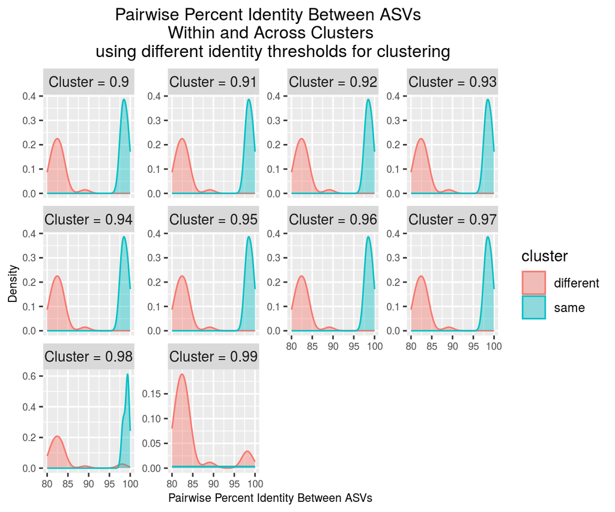

```r
outfile <- file.path(outdir, "5_cluster", "pairwise_identities_vsearch.csv")
plotfile <- file.path(outdir, "5_cluster", "plot_pairwise_identity_vsearch.png")

plot_vsearch <- plot_pairwise_identity_vsearch(
  read_count = read_count_sample_df,
  identity_min=0.9,
  identity_max=0.99,
  identity_increment=0.01,
  min_id = 0.8,
  vsearch_path=vsearch_path, # can be omitted if VSEARCH is in the PATH
  outfile=outfile,
  plotfile=plotfile,
  log_file = log_file)

print(plot_vsearch)
```

**Note:** This graph is based on a very small test dataset and is therefore not very informative.

Below is the same plot generated using the full (though still relatively small) original dataset, which provides a clearer view of the patterns:

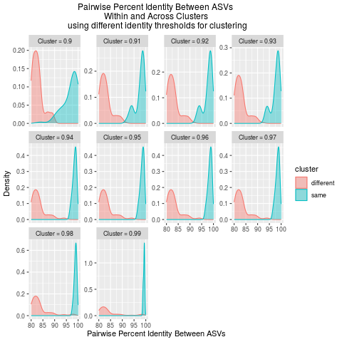

Pairwise Identity Plot per Cluster Identity Threshold for the original data

### Classify Clusters Based On Taxonomy

Clusters can also be evaluated using the taxonomic assignments of the ASVs they contain:

- `closed`: All ASVs in the cluster are assigned to the same taxon, and all ASVs from that taxon are found **only in this cluster**.
- `open`: All ASVs share the same taxonomic assignment, but other ASVs from that taxon are also found in **other clusters**.
- `hybrid`: The cluster contains ASVs assigned to **multiple taxa**.

You can perform this classification after clustering ASVs across a range of parameter values (`identity` for VSEARCH or `swarm_d` for SWARM), and then plot the number of clusters in each category for each setting.

A good clustering parameter typically maximizes the number of `closed` clusters while minimizing the number of `open` and `hybrid` clusters.

(See `?plot_cluster_classification` for more details.)

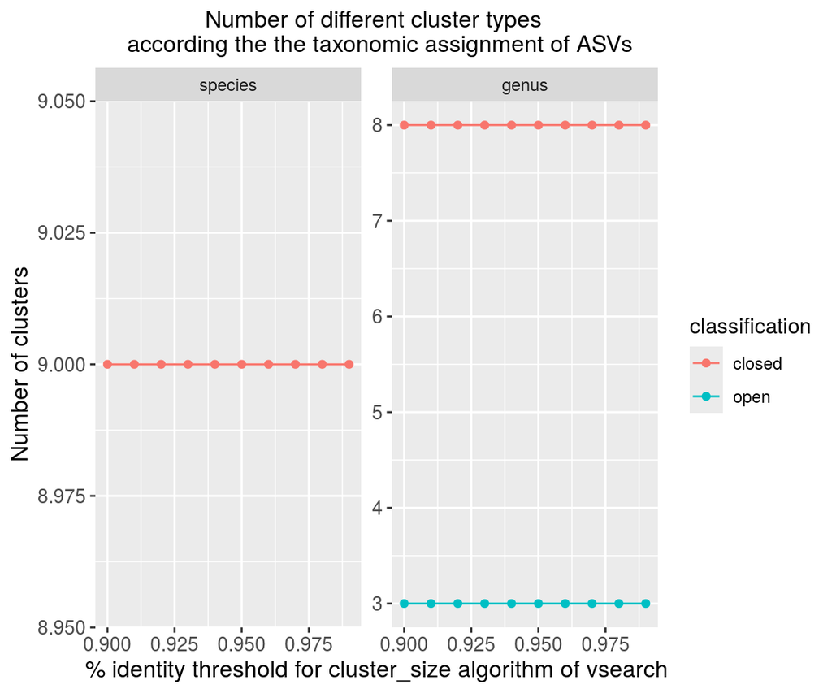

```r
outfile <- file.path(outdir, "5_cluster", "classification_vsearch.csv")
plotfile <- file.path(outdir, "5_cluster", "plot_cluster_classification_vsearch.png")

scatterplot_vsearch <- plot_cluster_classification(
  read_count = read_count_sample_df,
  taxa = asv_tax,
  clustering_method = "vsearch",
  cluster_params = c(0.90, 0.91, 0.92, 0.93, 0.94, 0.95, 0.96, 0.97, 0.98, 0.99),
  vsearch_path = vsearch_path, # can be omitted if VSEARCH is in the PATH
  taxlevels = c("species", "genus"),
  outfile = outfile,
  plotfile = plotfile,
  log_file = log_file)

print(scatterplot_vsearch)
```

**Note:** This graph is based on a very small test data set and is therefore not very informative.

Below is the same plot generated using the full (though still relatively small) original data set, which provides a clearer view of the patterns:

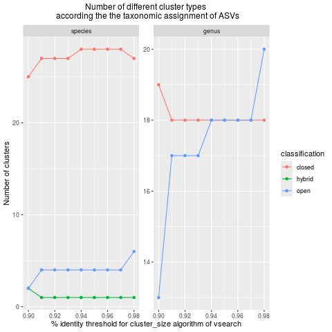

Plot ClusterClasstification for the original data

#### Interpretation of the plots

Even though the original dataset is relatively small and the differences between parameter values are not very pronounced, a few useful conclusions can still be drawn:

- For clustering thresholds below **0.94**, the distribution of pairwise identities among ASVs within the same cluster becomes **bimodal**. This likely indicates that ASVs from different taxa (e.g. species) are being grouped together, suggesting that the clustering threshold should be **at least 0.94**.
- The number of `closed` clusters at the species level is highest between **0.94 and 0.97**, while the number of `open` and `hybrid` clusters remains relatively low in this range.
- Overall, these results suggest that a clustering threshold between **0.94 and 0.97** is a good choice for defining mOTUs as proxies for species.

### Cluster ASVs into mOTUs

The `cluster_asv` function can cluster ASVs using either:

- VSEARCH (`method = "vsearch"`)
- SWARM (`method = "swarm"`)

The **output format** is controlled by the `group` argument:

- `group = TRUE`: ASVs in the same cluster are combined into a single row.
  - The `asv_id` and `asv` columns correspond to the **cluster centroid**
  - Read counts are summed across ASVs
- `group = FALSE`: The original ASV table is returned, with an additional `cluster_id` column. Each row still represents a single ASV

Clustering can be performed on the entire dataset (`by_sample = FALSE`) or separately for each sample (`by_sample = TRUE`). When defining mOTUs, it is recommended to cluster all ASVs together (`by_sample = FALSE`).

**Important:** If you cluster by sample (`by_sample = TRUE`) and use `group = FALSE`, the same `asv_id` may be assigned different `cluster_id` values in different samples, which can be confusing. This combination is therefore not recommended.

In this tutorial, we cluster the data using VSEARCH with an identity threshold of 0.97. (See `?cluster_asv` for guidance on parameter settings when using SWARM.)

```r
outfile <- file.path(outdir, "5_cluster", "16_mOTU_vsearch.csv")
identity <- 0.97
read_count_samples_df_ClusterSize <- cluster_asv(
  read_count = read_count_sample_df,
  method = "vsearch",
  identity = 0.97,
  group = TRUE,
  by_sample=FALSE,
  path=vsearch_path, # can be omitted if VSEARCH is in the PATH
  outfile=outfile,
  log_file = log_file)

stat_df <- get_stat(read_count_samples_df_ClusterSize,
                   stat_df,
                   stage="cluster_asv_vsearch",
                   param=identity)

knitr::kable(stat_df, format = "markdown")
```

|  | parameters | asv_count | read_count | sample_count | sample_replicate_count |
| --- | --- | --- | --- | --- | --- |
| input | NA | 10013 | 116447 | 4 | 12 |
| swarm_denoise | by_sample: TRUE split_clusters: TRUE | 1112 | 116446 | 4 | 12 |
| filter_asv_global | global_read_count_cutoff: 2 | 204 | 115538 | 4 | 12 |
| filter_indel | NA | 191 | 115364 | 4 | 12 |
| filter_stop_codon | genetic_code: 5 | 191 | 115364 | 4 | 12 |
| filter_contaminant | NA | 175 | 115249 | 4 | 12 |
| filter_chimera | by_sample: TRUE sample_prop: 0.8 abskew: 2 | 141 | 114682 | 4 | 12 |
| filter_replicate | renkonen_distance_quantile: 0.9 | 141 | 114655 | 4 | 11 |
| filter_occurrence_sample | cutoff: 0.004 | 51 | 112905 | 4 | 11 |
| filter_min_replicate | cutoff: 2 | 32 | 111561 | 4 | 11 |
| filter_occurrence_variant | cutoff: 0.001 | 32 | 111482 | 4 | 11 |
| filter_occurrence_read_count | cutoff: 10 | 31 | 111518 | 4 | 11 |
| pool_filters | NA | 31 | 111454 | 4 | 10 |
| filter_min_replicate_2 | cutoff: 2 | 30 | 111364 | 3 | 9 |
| cluster_asv_vsearch | 0.97 | 26 | 37378 | 3 | NA |

## Print Output

The `write_asv_table` function restructures your `read_count_df` so that:

- Samples appear in columns
- ASVs (or mOTU centroids) appear in rows

In other words, it converts the table from long format to wide format.

You can also include additional information in the output:

- Taxonomic assignments (`asv_tax`)
- Totals by ASV: total reads and number of samples for each ASV (`add_sums_by_asv`)
- Totals by sample: total reads and ASVs for each sample (`add_sums_by_sample`)
- Expected ASVs in mock samples: adds a column for each mock sample with its expected occurrences (`add_expected_asv`)
- Filtered samples: adds a column for samples that were filtered out (`add_empty_samples`)
- Cluster IDs: automatically retained if present in the input

If `pool_replicates = TRUE`, replicates within each sample are pooled, and the read count for each sample can be calculated as the **sum, mean, maximum, or minimum** of the read counts across replicates.

For more details, see `?write_asv_table`.

```r
outfile=file.path(outdir, "motu_table_taxa.csv")

asv_table_df <- write_asv_table(
  read_count = read_count_sample_df,
  outfile=outfile,
  asv_tax=asv_tax,
  sampleinfo=sampleinfo_df,
  add_empty_samples=FALSE,
  add_sums_by_sample=TRUE,
  add_sums_by_asv=TRUE,
  add_expected_asv=TRUE,
  mock_composition=mock_composition,
  log_file = log_file)
```

## Document your workflow

### Record R and package versions

The log file records all functions called during the analysis and the parameters used for each function. However, one important piece of information is still missing: the software environment in which the analysis was performed.

To ensure reproducibility, it is important to record the R version and the versions of all packages used. The information can be saved as a CSV file, which can be archived together with your results and will be useful when sharing or publishing your work.

```r
package_versions <- file.path(outdir, "R_package_versions.csv")
collect_package_info(package_versions)
```

### MIEM

Transparent and reproducible reporting is an essential part of environmental metabarcoding studies. The **Minimum Information for reporting of environmental metabarcoding data (MIEM)** guidelines ([Klymus et al. 2023](https://mbmg.pensoft.net/article/128689/)) provide recommendations for documenting the methods, data processing steps, and results required for a complete and reproducible study.

The **vtamR** package helps you compile most of the information of the **Methods - Bioinformatics and Reference Database** and  
**Results - Sequencing Summary Statistics** sections required by the MIEM guidelines directly from your analysis workflow. The `miem_bioinformatics()` function collects information about the bioinformatics pipeline, including the different analysis steps, software used, versions, and parameters, based on your `log_file` and `package_versions` files. The output can be used to easily fill the **Methods - Bioinformatics and Reference Database** section on the MIEM checlist.

The `miem_results()` function extracts key summary information from your results, such as the number of reads, ASVs, samples, and other relevant metrics and the output can be used to fill the **Results - Sequencing Summary Statistics** section.

The generated MIEM tables are designed to be almost ready for publication. Before submission, you should carefully review the output files and complete or adjust the sections that cannot be automatically retrieved by **vtamR**, such as study-specific descriptions or methodological details that require expert input.

**MIEM bioinformatics**

```r
miem_dir <- file.path(outdir, "MIEM")
miem_bioinformatics(
  log = log_file,
  r_versions = package_versions,
  outfile =  file.path(miem_dir, "MIEM_bioinfo.csv")
  )
```

**MIEM Sequencing Summary**

`info_files`: A vector containing the filenames of the information files generated during the different preprocessing steps of vtamR. These can be fastqinfo, fastainfo, or sampleinfo files.

The files are used to:

- calculate the total number of reads remaining after the different preprocessing steps;
- retrieve sample_type information from the final information file.

The last file in info_files is therefore particularly important, as it is used to determine the sample information.

`fastq_dir`: The directory containing the input FASTQ files. This parameter tells the function where to find the FASTQ files associated with the analysis.

`read_count_files`: A vector containing the read-count files generated during the vtamR pipeline. These files are used to summarize the number of reads retained at different filtering steps.

You can provide a read-count file from any filtering step. However, the two most informative files are usually:

- The first file, typically produced by dereplicate. It provides the number of reads and ASVs remaining after the main preprocessing steps, such as merging, demultiplexing, and quality filtering.
- The last file, corresponding to the final filtering step. It provides the number of reads and ASVs remaining after `vtamR` filtering, such as chimera removal and filtering of low-frequency or frequency-noise sequences.

The last file in read_count_files is also used to:

- count the number of ASVs or mOTUs assigned to each taxonomic rank;
- identify false-positive and false-negative taxonomic assignments.

```r
info_files = c(
  fastqinfo,
  "vtamR_demo_out/mfzr_plate1/1_merged/fastainfo.csv",
  "vtamR_demo_out/mfzr_plate1/2_random_seq/fastainfo.csv",
  "vtamR_demo_out/mfzr_plate1/3_demultiplexed/sampleinfo.csv"
)
read_count_files = c(
  "vtamR_demo_out/mfzr_plate1/4_filter/1_before_filter.csv",
  "vtamR_demo_out/mfzr_plate1/4_filter/2_swarm_denoise.csv",
  "vtamR_demo_out/mfzr_plate1/4_filter/14_filter_min_replicate.csv",
  "vtamR_demo_out/mfzr_plate1/4_filter/15_pool_replicates.csv",
  "vtamR_demo_out/mfzr_plate1/5_cluster/16_mOTU_vsearch.csv"
)
taxa = "vtamR_demo_out/mfzr_plate1/4_filter/assign_taxonomy_ltg.csv"
miem_results(
  info_files = info_files,
  fastq_dir = fastq_dir,
  read_count_files = read_count_files,
  taxa = taxa,
  outdir = miem_dir,
  mock_composition = mock_composition,
  )
```

## Multiple Datasets

### One Marker

The second plate of the MFZR marker can be processed in the same way as the first one.

Just make sure to:

- Use a **different output directory** to avoid overwriting results from the first plate
- Provide **`mfzr_plate1/ASV_list_with_IDs.csv`** as the `input_asv_list` in the `dereplicate` step. This ensures that ASV IDs remain consistent across both plates.

Let’s define a new output directory and log file.

```r
outdir <- file.path("vtamR_demo_out", "pooled_mfzr_plates")
log_file <- file.path(outdir, "vtamR_log_pooled_mfzr_plates.csv")
```

**Pool Filtered Datasets**

Filtered datasets can be easily combined using the long format (columns: `asv_id`, `sample`, `replicate` (optional), `read_count`, `asv`).

For pooling data from multiple plates, it is recommended to use the **filtered ASV tables** (e.g. `15_pool_replicates_xxx.csv`) before clustering into mOTUs. This helps avoid differences in cluster centroids between datasets.

In this example, we will:

- Pool filtered ASVs from the two MFZR plates
- Cluster the pooled ASVs into mOTUs
- Run taxonomic assignment on the centroids

#### Pool Datasets

```r
pooled_replicates_mfzr1 <-  system.file(
  "extdata/demo/15_pool_replicates_mfzr_plate1.csv",
  package = "vtamR"
  )
pooled_replicates_mfzr2 <-  system.file(
  "extdata/demo/15_pool_replicates_mfzr_plate2.csv",
  package = "vtamR"
  )

filtered_files <- c(
  pooled_replicates_mfzr1,
  pooled_replicates_mfzr2
  )

outfile <- file.path(outdir, "filtered_asv.csv")
pooled_read_count_df <- pool_datasets(
  files = filtered_files,
  outfile = outfile,
  method = "mean",  # If a sample appears in multiple plates, take the mean read count
  log_file = log_file
)
```

#### Make mOTUs from Pooled Data

```r
outfile <- file.path(outdir, "motu.csv")
identity <- 0.97

read_count_motu <- cluster_asv(
  read_count = pooled_read_count_df,
  method = "vsearch",
  identity = 0.97,
  group = TRUE,
  path=vsearch_path, # can be omitted if VSEARCH is in the PATH
  outfile=outfile,
  log_file = log_file
  )
```

#### Assign Taxa to Pooled Data

While you could reuse taxonomic assignments from previous runs, it is usually simpler to rerun the assignment on the pooled dataset.

```r
outfile <- file.path(outdir, "tax_assign_ltg.csv")

asv_tax_pooled <- assign_taxonomy_ltg(
  asv=read_count_motu,
  taxonomy=taxonomy,
  blast_db=blast_db,
  blast_path=blast_path, # can be omitted if BLAST is in the PATH
  outfile=outfile,
  log_file = log_file
  )
```

#### Print ASV table

```r
outfile=file.path(outdir, "motu_table_taxa.csv")

asv_table_df <- write_asv_table(
  read_count = read_count_motu,
  outfile=outfile,
  asv_tax=asv_tax_pooled,
  add_sums_by_sample=T,
  add_sums_by_asv=T,
  log_file = log_file
  )
```

### More than One Overlapping Markers

Using two or more **overlapping markers** on the same samples can improve the taxonomic coverage of PCR amplification.

Each marker should first be analyzed separately. The results can then be combined by aggregating ASVs that are identical in their overlapping region.

As with the second plate of the MFZR marker, the first plate of ZFZR can be processed in the same way.

Make sure to:

- Use a different output directory to avoid overwriting previous results
- Provide `mfzr_plate2/ASV_list_with_IDs.csv` as the `input_asv_list` in the `dereplicate` step. This ensures that **ASV IDs remain consistent** across both plates and markers.

The corresponding results are included in the package:

```r
mfzr_filtered <-  system.file(
  "extdata/demo/15_pool_replicates_mfzr_plate1.csv",
  package = "vtamR"
  )
zfzr_filtered <-  system.file(
  "extdata/demo/15_pool_replicates_zfzr_plate1.csv",
  package = "vtamR"
  )
```

Let’s define a new output directory and log file.

```r
outdir <- file.path("vtamR_demo_out", "pooled_markers")
log_file <- file.path(outdir, "vtamR_log_pooled_markers.csv")
```

If you have consistently used the `ASV_list_with_IDs.csv` from previous runs for processing the ZFZR plate, the ASV IDs are already compatible and can be used directly.

If the ASV IDs are **not compatible** (for example, the same `asv_id` refers to different sequences across markers), you can fix this by assigning a numerical identifier to each marker, for instance, `1` for MFZR and `2` for ZFZR in this example.

These identifiers are appended to the ASV IDs, keeping them unique and preventing confusion between markers.

```r
input_files <- c(mfzr_filtered, zfzr_filtered)
marker_ids <- c(1, 2)

outfile <- file.path(outdir, "filtered_asv.csv")
asv_with_centroids <- file.path(outdir, "filtered_asv_with_centroids.csv")

pooled_markers <- pool_markers(
  files = input_files,
  marker_ids = marker_ids,
  outfile = outfile,  # ASVs identical over their overlapping region are merged into a single line
  asv_with_centroids = asv_with_centroids,  # same as input, with added centroid_id and centroid
  method = "mean",  # mean read counts across pooled ASVs
  vsearch_path = "vsearch",
  quiet = TRUE,
  log_file = log_file
)
```

#### Make mOTU - Taxassign - mOTU table

As with multiple datasets for a single marker, we will cluster the ASVs from the pooled dataset into mOTUs, then assign the sequences to taxa, and finally create an mOTU table.

```r
#### Cluster
outfile <- file.path(outdir, "motu.csv")
identity <- 0.97
read_count_motu <- cluster_asv(
  read_count = pooled_markers,
  method = "vsearch",
  identity = 0.97,
  group = TRUE,
  path=vsearch_path,
  outfile=outfile,
  log_file = log_file
  )

#### TaxAssign
outfile <- file.path(outdir, "assign_taxonomy_ltg.csv")

asv_tax_pooled <- assign_taxonomy_ltg(
  asv=read_count_motu,
  taxonomy=taxonomy,
  blast_db=blast_db,
  blast_path=blast_path,
  outfile=outfile,
  log_file = log_file
  )

#### Print mOTU table
outfile <- file.path(outdir, "motu_table_taxa.csv")

asv_table_df <- write_asv_table(
  read_count = read_count_motu,
  outfile=outfile,
  asv_tax=asv_tax_pooled,
  add_sums_by_sample=T,
  add_sums_by_asv=T,
  log_file = log_file
  )
```

# Tips - Good to Know

## Data Frame or CSV File

Most `vtamR` functions can take either a data frame or a CSV file as input.

This is useful if you want to resume your analysis without rerunning earlier steps. For example, if you’ve closed your R session but saved your data frame to a file.

### Arguments Accepting Data Frame or CSV

Many function arguments can accept either format, as long as the file or data frame contains the required columns. Common examples include:

- `read_count`
- `fastqinfo`
- `fastainfo`
- `sampleinfo`
- `input_asv_list`
- `mock_composition`
- `asv`
- `ltg_params`
- `asv_tax`

Check the **help page** of each function for the exact required columns: `?function_name`.

### Function Outputs

Many functions return a data frame. If you also specify `outfile`, the function will write the data frame to a CSV file at the same time.

Saving outputs as CSV is a good practice for long workflows. It allows you to:

- Inspect the dataset after each filtering step
- Resume processing later without rerunning earlier steps

## To Compress or Not to Compress

During the first steps of the workflow (`merge_fastq_pairs`, `subsample_fasta`, `trim_primers`, `demultiplex_and_trim_fasta`), many intermediate files are generated. Some of these files can be very large, especially before dereplication (`dereplicate`).

### File Size vs. Processing Time

Compressing and decompressing files between steps can take significant time. For this reason, `vtamR` outputs uncompressed files by default to speed up processing.

However, uncompressed files can quickly consume disk space. Remember to delete intermediate files once your analysis is complete. See Files to Keep for guidance on which files to retain.

If storage is limited, you can enable file compression by setting `compress = TRUE` in relevant functions (e.g., `subsample_fasta`, `trim_primers`, `demultiplex_and_trim_fasta`). This produces **gzip-compressed output files**.

### Compression Methods

The method used is controlled by the `compress_method` argument. Three options are available:

- `"pigz"` – Uses the `PIGZ` program (parallel gzip). Requires installation, and if not in the system `PATH`, its location must be provided via `pigz_path`. Works on Linux-like systems and Windows. Uses multithreading, making it the fastest option.
- `"gzip"` – Uses the standard `gzip` command available on Linux-like systems. Slower than `pigz` and not available on Windows.
- `"R"` – Implemented in R via the `R.utils` package. Cross-platform, works everywhere, but is the slowest method.

### Example: Compression Speed Comparison

For a 19 GB FASTA file (compressed size: 3 GB) on Linux:

| Method | Compression (min) | Decompression (min) |
| --- | --- | --- |
| R.utils | 16 | 3 |
| gzip | 13 | 3 |
| pigz | 3 | 2 |

### Summary

- The fastest workflow is to avoid compression during processing and clean up intermediate files afterward.
- If you want compressed files, `PIGZ` is clearly the best option.
- See Installation for setup instructions.

### Notes on Compatibility

The effect of compression may vary depending on which external programs are used:

- CUTADAPT and VSEARCH can often process gzip-compressed files directly.
- On Windows, some VSEARCH commands may not accept compressed files.
- CUTADAPT can produce gzip-compressed outputs on all systems.
- VSEARCH usually outputs uncompressed files, even when reading compressed inputs.

## Detection of False Positives (FP), True Positives (TP), and False Negatives (FN)

The function `classify_control_occurrences` identifies occurrences as **false positives**, **false negatives**, or **true positives** based on control samples and habitat context.

- **True Positives (TP):** All expected occurrences detected in a mock sample (i.e., ASVs that correspond to the species intentionally included in the mock community).
- **False Negatives (FN):** Expected ASVs in the mock samples that are **not detected** during analysis.
- **False Positives (FP):**
  - **Unexpected ASVs** in mock samples (ASVs not included in the mock community).
  - **All ASVs detected in negative controls** (indicating contamination or technical artifacts).
  - **Habitat-inconsistent ASVs:** ASVs detected in a sample but unexpected for its habitat. If samples or mocks originate from distinct habitats (e.g., seawater vs. terrestrial), the function evaluates the proportion of reads for each ASV across habitats. If the proportion of reads for an ASV in a given habitat is below the `habitat_proportion` threshold, the ASV is flagged as a false positive for all samples from that habitat.

## Clustering or Denoising

The `cluster_asv` function supports two algorithms for grouping ASVs:

### Available Methods

**`method = "vsearch"`** Uses VSEARCH’s `cluster_size` command, a **greedy, centroid-based algorithm**. ASVs are sorted by decreasing read count, so the most abundant ASVs become cluster centroids. The cluster radius is controlled by the `identity` parameter.

**`method = "swarm"`** Uses SWARM, a **fast, iterative algorithm** that clusters ASVs differing by `d` or fewer nucleotides. Clusters form naturally around local abundance peaks and are mostly insensitive to the input order.

> Although both approaches perform *clustering*, they are often used for **different goals**.

### Denoising vs. Clustering

#### 1. Denoising

SWARM was originally designed as a **denoising** method for metabarcoding data. The principle is simple:

> True biological ASVs tend to have high read counts, while very similar ASVs with lower read counts are likely sequencing errors.

Denoising groups likely erroneous sequences into the cluster of their true ASV, preserving ASV-level diversity.

Running SWARM with `d = 1` and the *fastidious* option activated corresponds to this denoising goal.

**Limitation:** If two real biological variants differ by only one mutation, they may be merged, causing some loss of true variability.

**Tip:** While `cluster_asv` can run SWARM with `d = 1` for denoising, the **`denoise_by_swarm`** function is specifically designed for this purpose. It runs SWARM with the same settings but adds a **`split_clusters`** option to retain intra-specific variability. After running SWARM sample by sample, clusters that contain ASVs with high relative abundance compared to the centroid can be split, preserving biologically meaningful diversity.

#### 2. Clustering

**Clustering** aims to group ASVs (both true and erroneous) into units approximating biological taxa (species, genera, etc.).

- VSEARCH (`cluster_size`) uses a fixed identity threshold for this.
- SWARM with larger `d` values can also produce taxon-like clusters.

Choosing the right threshold depends on the genetic marker and taxonomic group. `vtamR` provides tools to explore clustering outcomes across multiple thresholds.

### Tools for Choosing a Clustering Threshold

#### 1. Pairwise Identity Plots

For a range of thresholds, `vtamR` can generate density plots of pairwise identities:

- `plot_pairwise_identity_vsearch()` – for VSEARCH thresholds
- `plot_pairwise_identity_swarm()` – for SWARM `d` values

These plots show how ASV similarities vary **within** and **between** clusters.

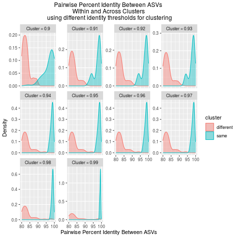

Pairwise Identity Plot per Cluster Identity Threshold for the original data

#### 2. Cluster Classification

Clusters can also be classified based on the **taxonomic assignments** of the ASVs they contain:

- **closed**: All ASVs share the same taxon, and that taxon appears only in this cluster.
- **open**: All ASVs share the same taxon, but the same taxon also appears in other clusters.
- **hybrid**: The cluster contains ASVs assigned to different taxa.

The function `PlotClusterClassification()` shows the number of clusters in each class across thresholds.

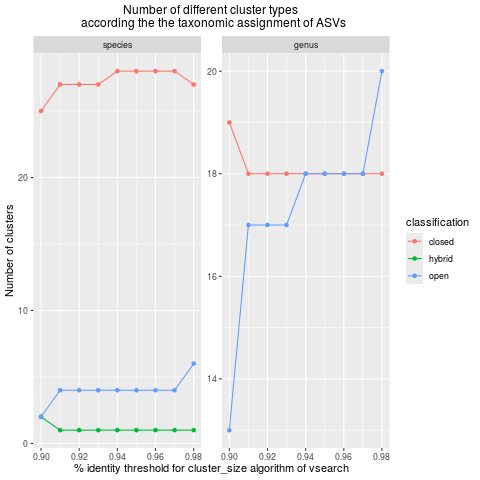

Plot Cluster Classification for the original data

### Interpreting the Plots

These visualizations help you choose an appropriate clustering threshold:

- Check if clusters are taxonomically coherent.
- See how identity (`VSEARCH`) or `d` (`SWARM`) affects cluster structure.
- Find a balance between over-splitting and over-merging biological units.

For more guidance, see the Make mOTUs section.

## Arguments

### `num_threads`

By default, vtamR automatically uses all available CPU cores for multithreaded processes. If you want to maximize performance, there is no need to specify the `num_threads` argument.

However, you may want to limit the number of cores used—for example, to leave resources for other tasks or users. In that case, simply set the `num_threads` argument in the relevant function.

**Example:** This limits `merge_fastq_pairs` to use **8 CPU threads**:

```r
fastainfo_df <- merge_fastq_pairs(
  fastqinfo,
  fastq_dir = fastq_dir,
  vsearch_path = vsearch_path, # can be omitted if VSEARCH is in the PATH
  outdir = merged_dir,
  num_threads = 8
  )
```

### `quiet`

Some external programs used by vtamR can produce a lot of console output, even when they are run in their own “quiet” mode. This can make it hard to spot important warnings or errors.

The `quiet` argument controls whether this output is displayed:

- `quiet = TRUE` (default): suppresses most messages, keeping logs clean.
- `quiet = FALSE`: shows all output, which can be useful for troubleshooting.

**Tip:** If a function fails or behaves unexpectedly, rerun it with `quiet = FALSE` to inspect the full messages and identify the problem.

### `sep`

The `sep` argument defines the separator used in CSV files.

- Default: `","` (comma)
- Recommendation: Use the same separator in all CSV files to ensure consistency.

**Exception:** The taxonomy file of the reference database must be tab-separated (`\t`).

### PATH Variables

Some vtamR functions rely on external programs such as VSEARCH, CUTADAPT, BLAST, SWARM, or PIGZ. To use these tools, vtamR needs to know where their executables are located.

- If these programs are already in your **system PATH**, vtamR will find them automatically. You don’t need to specify their locations when calling functions.
- If the programs are **not in your PATH**, you must provide their paths explicitly using the relevant arguments:

```r
vsearch_path  # Path to VSEARCH
cutadapt_path # Path to CUTADAPT
blast_path    # Path to BLAST
swarm_path    # Path to SWARM
pigz_path     # Path to PIGZ
```

To see which external tools a function requires, check its help page: `?function_name`

## Files to Keep

During the first steps of the workflow (`merge_fastq_pairs`, `subsample_fasta`, `Sortreads`, `trim_primers`), many intermediate files are generated, and some can be very large, especially before dereplication (`dereplicate`).

Compressing and decompressing files between steps can take time, so vtamR produces uncompressed files by default. You can change this behavior using the compress option.

Here’s a practical guide on what to keep, delete, or compress:

- `merge_fastq_pairs`:
  - Delete the output FASTA files.
  - Keep `fastainfo.csv` for read count information after merging.
- `subsample_fasta`:
  - Compress the FASTA files.
  - Keep them to ensure reproducibility in case of re-analysis.
- `demultiplex_and_trim_fasta`:
  - Delete the output FASTA files.
  - Keep `sampleinfo.csv` for read count information after trimming.
- `dereplicate`:
  - Save the dereplicated information to a file (e.g., `1_before_filter.csv` in the tutorial).
  - Compress after analysis.
  - This file is important, as you can restart analyses from here without redoing the long merging and demultiplexing steps.
  - Compress and keep the updated ASV list (`ASV_list_with_IDs.csv`), which can be reused for later datasets to synchronize `asv_id`s.
- Output of filtering steps:
  - Compress if files are large.
  - Useful for tracing the history of a sample or ASV (see history_by) or for making summary files (see summarize_by).

This strategy balances disk space and reproducibility, keeping only the essential information to resume or audit your analyses.

# Supplementary Functions

## `filter_pcr_error`

If you have already performed **denoising** using **SWARM** (`denoise_by_swarm`), this function may be redundant, as denoising already removes many likely PCR/sequencing errors.

`filter_pcr_error` works by flagging an ASV as a PCR error if it is very similar to a more abundant ASV.

- `max_mismatch`: maximum number of mismatches allowed between two ASVs to evaluate for PCR error.
- `pcr_error_var_prop`: if the less abundant ASV has a read count proportion ≤ this value relative to the more abundant ASV, it is flagged as a PCR error. Default = 0.1 (arbitrary).

**Example**

This will remove ASVs likely caused by PCR errors, cleaning your dataset for downstream analyses. For more details and advanced options, see `?filter_pcr_error`.

```r
outfile <- file.path(outdir, "filter_pcr_error.csv")

read_count_df <- filter_pcr_error(
  read_count_df,
  outfile=outfile,
  vsearch_path=vsearch_path,
  pcr_error_var_prop=0.15
  )
```

## `suggest_pcr_error_cutoff`: Suggesting a PCR Error Cutoff

The default `pcr_error_var_prop` may not be ideal for your dataset. Use `suggest_pcr_error_cutoff` to guide the choice.

This function:

- Finds highly similar ASV pairs (default `max_mismatch = 1`) in mock samples where one ASV is expected and the other is not.
- Computes the read count ratio of the less abundant ASV to the more abundant ASV.
- Considers only ASVs with more than `min_read_count` reads (default = 5) to avoid stochastic noise from very low counts.

The output CSV lists all pairs, sorted by decreasing `pcr_error_var_prop`. The highest read count ratio observed among unexpected ASVs can be used as a **lower bound** for `pcr_error_var_prop`.

```r
outfile <- file.path(outdir, "suggest_parameters", "suggest_pcr_error_cutoff.csv")

suggest_pcr_error_cutoff_df <- suggest_pcr_error_cutoff(
  read_count_df,
  mock_composition=mock_composition,
  vsearch_path=vsearch_path,
  outfile=outfile
  )
```

> **Tip:** If you do not yet have the exact sequences for your mock samples, see How to make a mock_composition file before running this function.

## `subsample_fasta`

The `subsample_fasta` function randomly selects `n` sequences (without replacement) from each input FASTA file listed in the `fastainfo` data frame.

This step is useful for normalizing sequencing depth across libraries. It can be applied before or after demultiplexing (`demultiplex_and_trim_fasta`).

> **Note:** If your workflow includes `filter_occurrence_variant` or `filter_occurrence_read_count`, which rely on total reads in negative controls, standardizing read numbers across samples is **not recommended**. Typically, `subsample_fasta` is applied after `merge_fastq_pairs` but before `demultiplex_and_trim_fasta` to ensure all replicate series have the same number of reads.

**Available Algorithms**

*1. Using VSEARCH (`use_vsearch = TRUE`)*

- Uses the [`fastx_subsample`](https://github.com/torognes/vsearch) command from VSEARCH.
- Very fast, but only available on Linux-like systems.
- Supports compression of input/output files using:
  - `pigz`: fastest, multithreaded, requires `pigz_path` if not in `PATH`.
  - `gzip`: slower, Linux only.
  - `R`: cross-platform but slowest (via `R.utils`).

*2. Using R only (`use_vsearch = FALSE`)*

- Performs sampling entirely in R.
- Works on all operating systems.
- No external dependencies or compression tools required.
- Slower than VSEARCH, especially for large FASTA files.

**Input Parameters**

- `fastainfo` – CSV file or data frame with columns: `tag_fw`, `primer_fw`, `tag_rv`, `primer_rv`, `sample`, `sample_type`, `habitat`, `replicate`, `fasta`.
- `fasta_dir` – Directory containing input FASTA files.
- `n` – Number of sequences to sample (without replacement).
- `outdir` – Directory for output FASTA files.
- `use_vsearch` – Whether to use VSEARCH for fast sampling.
- `compress` – Whether to compress output files (`TRUE` or `FALSE`).
- `compress_method` – `"pigz"`, `"gzip"`, or `"R"`.

**Example: Fast Version (Linux-like systems)**

```r
randomseq_dir <- file.path(outdir, "random_seq")

fastainfo_df <- subsample_fasta(
                fastainfo    = fastainfo_df,
                fasta_dir    = merged_dir,
                outdir       = randomseq_dir,
                use_vsearch  = TRUE,
                vsearch_path = vsearch_path, # can be omitted if VSEARCH is in the PATH
                compress_method = "pigz",
                pigz_path    = pigz_path, # can be omitted if PIGZ is in the PATH
                n            = 10000,
                compress     = TRUE)
```

**Example: Cross-Platform Version**

```r
randomseq_dir <- file.path(outdir, "random_seq")

fastainfo_df <- subsample_fasta(
                fastainfo    = fastainfo_df,
                fasta_dir    = merged_dir,
                outdir       = randomseq_dir,
                use_vsearch  = FALSE,
                n            = 10000,
                compress     = TRUE)
```

> **Tip:** Choose `use_vsearch = TRUE` when possible for speed. Use `FALSE` for **Windows or macOS**, or when VSEARCH is not installed.

## `classify_control_occurrences`

The function `classify_control_occurrences` identifies occurrences as **false positives**, **false negatives**, or **true positives** based on control samples and habitat context.

- **True Positives (TP):** All expected occurrences detected in a mock sample (i.e., ASVs that correspond to the species intentionally included in the mock community).
- **False Negatives (FN):** Expected ASVs in the mock samples that are **not detected** during analysis.
- **False Positives (FP):**
  - **Unexpected ASVs** in mock samples (ASVs not included in the mock community).
  - **All ASVs detected in negative controls** (indicating contamination or technical artifacts).
  - **Habitat-inconsistent ASVs:** ASVs detected in a sample but unexpected for its habitat. If samples or mocks originate from distinct habitats (e.g., seawater vs. terrestrial), the function evaluates the proportion of reads for each ASV across habitats. If the proportion of reads for an ASV in a given habitat is below the `habitat_proportion` threshold, the ASV is flagged as a false positive for all samples from that habitat.

**Outputs**

- `known_occurrences`: Data frame (or CSV file) containing:
  - True positive occurrences
  - False positive occurrences
- `false_negatives`: Data frame (or CSV file) of ASVs that were expected in mock samples but not detected.
- `performance_metrics`: Data frame summarizing counts of true positives, false positives, and false negatives.

> For details on parameters and options, see `?classify_control_occurrences`.

**Input Requirements**

- `read_count_df`: Data frame containing ASV read counts for each sample.
- `sampleinfo_df`: Must include columns: `sample`, `sample_type`, `replicate`, and `habitat`. Any data frame with these columns is acceptable. The easiest is the output of `demultiplex_and_trim_fasta`

> **Tip:** If you restarted the analysis after `demultiplex_and_trim_fasta` and `sampleinfo_df` is not in memory, use the **sampleinfo CSV file** in `vtamR_demo_out/demultiplexed`.

**Notes**

- If you do **not** know the exact sequences in your mock samples, you will need the **mock_composition file** before running this function. See How to make a mock_composition file for guidance.
- This function is particularly useful to assess the performance of filtering steps.

```r
# Detect known occurrences
results <- classify_control_occurrences(read_count = read_count_df,
                                sampleinfo=sampleinfo_df,
                                mock_composition=mock_composition)

# give explicit names to the 3 output data frames
known_occurrences_df <- results[[1]]
false_negatives_df <- results[[2]]
performance_metrics_df <- results[[3]]
```

## `compute_asv_specific_cutoff`

Some ASVs may appear in many samples with high read counts, which can make them resistant to a fixed cutoff in `filter_occurrence_variant`. This can occur due to **tag-jump** or inter-sample contamination.

The `compute_asv_specific_cutoff` function computes ASV-specific cutoff values for variants with known false-positive occurrences (identified by `classify_control_occurrences`), so filtering can be more targeted.

**How It Works**

For each ASV:

1. Identify all **false-positive occurrences**.
2. Take the **maximum read count** among these false positives.
3. Divide this value by the **total read count** of the ASV across all samples, or within each replicate if `by_replicate = TRUE`.

> Some false positives may not be due to tag-jump, so raw cutoff values can be excessively high.
> - Filter the dataset thoroughly before computing ASV-specific cutoffs.
> - Use the `max_cutoff` parameter to set a reasonable upper limit.

**Example**

```r
asv_spec <- compute_asv_specific_cutoff(
  read_count_df,
  max_cutoff=0.05,
  mock_composition=mock_composition_df
  )
```

*Output:* A data frame `asv_spec` with columns:

- `asv_id`: Identifier of the ASV
- `cutoff_asv_spec`: ASV-specific cutoff, capped at `max_cutoff = 0.05`

> Only ASVs with **known false-positive occurrences** are included.

**Using ASV-Specific Cutoffs in Filtering**

Pass `asv_spec` to `filter_occurrence_variant`:

```r
read_count_df <- filter_occurrence_variant(
  read_count_df,
  asv_specific_cutoffs = asv_spec,
  min_read_count_prop=0.7
  )
```

- A warning is issued if less than `min_read_count_prop` of reads remain for some ASVs after filtering. This suggests the cutoff may be too high and should be reduced.

**Combining Global and ASV-Specific Cutoffs**

You can also use a global cutoff together with ASV-specific cutoffs.

- The global `cutoff` is applied to:
  - ASVs **without** an ASV-specific cutoff
  - ASVs whose ASV-specific cutoff is **lower** than the global cutoff

```r
read_count_df <- filter_occurrence_variant(
  read_count_df,
  cutoff=0.002,
  asv_specific_cutoffs = asv_spec,
  min_read_count_prop=0.7
  )
```

This approach allows flexible, per-ASV filtering while maintaining a minimum global threshold for all other variants.

## `assign_taxonomy_rdp`

**Taxonomic assignment using the RDP classifier**

For **16S rRNA** data, the **RDP (Ribosomal Database Project)** provides a curated reference database for Bacteria and Archaea. The **pre-trained sets** are included in the **`rRDPData`** package, and the **`rRDP`** package performs the taxonomic classification.

**Installing `rRDP` and `rRDPData`** {#install-rdp}

These packages are available through **Bioconductor** and are **not installed automatically** with `vtamR`:

```r
if (!requireNamespace("BiocManager", quietly = TRUE))
    install.packages("BiocManager")

BiocManager::install("rRDP")
BiocManager::install("rRDPData")
```

**Running the RDP classifier via vtamR**

The `assign_taxonomy_rdp()` function is a wrapper around the RDP classifier, allowing direct application to your ASV dataset.

```r
taxa <- assign_taxonomy_rdp(
  asv=read_count_df,
  max_memory = 8,
  confidence = 0.8,
  rm_chloroplast = TRUE
  )
```

**Arguments:**

- `asv`: CSV file path or data frame containing at least:
  - `asv_id`: unique numeric identifier
  - `asv`: nucleotide sequence
- `max_memory`: RAM available for RDP (GB)
- `confidence`: minimum confidence threshold for assignment
- `rm_chloroplast`: if `TRUE`, sequences classified as *Chloroplast* are replaced with `NA`

**Using a Custom RDP Training Set**

You can provide your own RDP-trained dataset instead of the default from `rRDPData`. This requires a folder containing the trained classifier created with `trainRDP()`:

```r
taxa <- assign_taxonomy_rdp(
  asv=read_count_df,
  dir="path/to/custom_RDP_trained_DB"
  max_memory = 8,
  confidence = 0.8,
  rm_chloroplast = TRUE)
```

For more details, see `?rRDP::rdp` for training and using custom classifiers.

## `history_by`

The `history_by` function allows you to **track the filtering history** of specific features (ASVs, samples, or replicates) across multiple filtering steps.

**How It Works**

- Scans all files in a directory (`dir`) whose names mathch a `pattern` (by default start with a number). These are typically the outputs from different filtering steps.
- Selects all rows where the selected **feature** matches any of the **values** provided in a vector. **Key Arguments**
- `dir`: Path to the directory containing the filtering output files.
- `feature`: Column to track (`asv_id`, `asv`, `sample`, or `replicate`).
- `values`: The specific value of the feature you want to follow.

**Examples**

*Get the history of asv_id (`feature`) 27 (`value`).*

```r
filter_dir <- file.path("vtamR_demo_out", "mfzr_plate1", "4_filter")
tmp_ASV <- history_by(dir=filter_dir,
                        feature="asv_id",
                        values=c(4, 27)
)

knitr::kable(head(tmp_ASV), format = "markdown")
```

| file | asv_id | sample | replicate | read_count | asv |
| --- | --- | --- | --- | --- | --- |
| 1_before_filter.csv | 27 | tpos1 | 1 | 1 | ACTATACCTTATCTTCGCAGTATTCTCAGGAATGCTAGGAACTGCTTTTAGTGTTCTTATTCGAATGGAACTAACATCTCCAGGTGTACAATACCTACAGGGAAACCACCAACTTTACAATGTAATCATTACAGCTCACGCATTCCTAATGATCATTTTCATGGTTATGCCAGGACTTGTT |
| 1_before_filter.csv | 4 | tpos1 | 1 | 256 | CTTATATTTTATTTTTGGTGCTTGATCAGGGATAGTGGGAACTTCTTTAAGAATTCTTATTCGAGCTGAACTTGGTCATGCGGGATCTTTAATCGGAGACGATCAAATTTACAATGTAATTGTTACTGCACACGCCTTTGTAATAATTTTTTTTATAGTTATACCTATTTTAATT |
| 1_before_filter.csv | 4 | tpos1 | 2 | 236 | CTTATATTTTATTTTTGGTGCTTGATCAGGGATAGTGGGAACTTCTTTAAGAATTCTTATTCGAGCTGAACTTGGTCATGCGGGATCTTTAATCGGAGACGATCAAATTTACAATGTAATTGTTACTGCACACGCCTTTGTAATAATTTTTTTTATAGTTATACCTATTTTAATT |
| 1_before_filter.csv | 4 | tpos1 | 3 | 210 | CTTATATTTTATTTTTGGTGCTTGATCAGGGATAGTGGGAACTTCTTTAAGAATTCTTATTCGAGCTGAACTTGGTCATGCGGGATCTTTAATCGGAGACGATCAAATTTACAATGTAATTGTTACTGCACACGCCTTTGTAATAATTTTTTTTATAGTTATACCTATTTTAATT |
| 2_swarm_denoise.csv | 4 | tpos1 | 1 | 332 | CTTATATTTTATTTTTGGTGCTTGATCAGGGATAGTGGGAACTTCTTTAAGAATTCTTATTCGAGCTGAACTTGGTCATGCGGGATCTTTAATCGGAGACGATCAAATTTACAATGTAATTGTTACTGCACACGCCTTTGTAATAATTTTTTTTATAGTTATACCTATTTTAATT |
| 2_swarm_denoise.csv | 4 | tpos1 | 2 | 324 | CTTATATTTTATTTTTGGTGCTTGATCAGGGATAGTGGGAACTTCTTTAAGAATTCTTATTCGAGCTGAACTTGGTCATGCGGGATCTTTAATCGGAGACGATCAAATTTACAATGTAATTGTTACTGCACACGCCTTTGTAATAATTTTTTTTATAGTTATACCTATTTTAATT |

*Get the history of a sequence of the ASV (`feature`).*

```r
tmp_ASV <- history_by(
  dir=filter_dir,
  feature="asv",
  values="ACTATATTTTATTTTTGGGGCTTGATCCGGAATGCTGGGCACCTCTCTAAGCCTTCTAATTCGTGCCGAGCTGGGGCACCCGGGTTCTTTAATTGGCGACGATCAAATTTACAATGTAATCGTCACAGCCCATGCTTTTATTATGATTTTTTTCATGGTTATGCCTATTATAATC"
  )

knitr::kable(tmp_ASV, format = "markdown")
```

| file | asv_id | sample | replicate | read_count | asv |
| --- | --- | --- | --- | --- | --- |
| 1_before_filter.csv | 1 | tpos1 | 1 | 375 | ACTATATTTTATTTTTGGGGCTTGATCCGGAATGCTGGGCACCTCTCTAAGCCTTCTAATTCGTGCCGAGCTGGGGCACCCGGGTTCTTTAATTGGCGACGATCAAATTTACAATGTAATCGTCACAGCCCATGCTTTTATTATGATTTTTTTCATGGTTATGCCTATTATAATC |
| 1_before_filter.csv | 1 | tpos1 | 2 | 188 | ACTATATTTTATTTTTGGGGCTTGATCCGGAATGCTGGGCACCTCTCTAAGCCTTCTAATTCGTGCCGAGCTGGGGCACCCGGGTTCTTTAATTGGCGACGATCAAATTTACAATGTAATCGTCACAGCCCATGCTTTTATTATGATTTTTTTCATGGTTATGCCTATTATAATC |
| 1_before_filter.csv | 1 | tpos1 | 3 | 66 | ACTATATTTTATTTTTGGGGCTTGATCCGGAATGCTGGGCACCTCTCTAAGCCTTCTAATTCGTGCCGAGCTGGGGCACCCGGGTTCTTTAATTGGCGACGATCAAATTTACAATGTAATCGTCACAGCCCATGCTTTTATTATGATTTTTTTCATGGTTATGCCTATTATAATC |
| 2_swarm_denoise.csv | 1 | tpos1 | 1 | 520 | ACTATATTTTATTTTTGGGGCTTGATCCGGAATGCTGGGCACCTCTCTAAGCCTTCTAATTCGTGCCGAGCTGGGGCACCCGGGTTCTTTAATTGGCGACGATCAAATTTACAATGTAATCGTCACAGCCCATGCTTTTATTATGATTTTTTTCATGGTTATGCCTATTATAATC |
| 2_swarm_denoise.csv | 1 | tpos1 | 2 | 247 | ACTATATTTTATTTTTGGGGCTTGATCCGGAATGCTGGGCACCTCTCTAAGCCTTCTAATTCGTGCCGAGCTGGGGCACCCGGGTTCTTTAATTGGCGACGATCAAATTTACAATGTAATCGTCACAGCCCATGCTTTTATTATGATTTTTTTCATGGTTATGCCTATTATAATC |
| 2_swarm_denoise.csv | 1 | tpos1 | 3 | 98 | ACTATATTTTATTTTTGGGGCTTGATCCGGAATGCTGGGCACCTCTCTAAGCCTTCTAATTCGTGCCGAGCTGGGGCACCCGGGTTCTTTAATTGGCGACGATCAAATTTACAATGTAATCGTCACAGCCCATGCTTTTATTATGATTTTTTTCATGGTTATGCCTATTATAATC |
| 3_filter_asv_global.csv | 1 | tpos1 | 1 | 520 | ACTATATTTTATTTTTGGGGCTTGATCCGGAATGCTGGGCACCTCTCTAAGCCTTCTAATTCGTGCCGAGCTGGGGCACCCGGGTTCTTTAATTGGCGACGATCAAATTTACAATGTAATCGTCACAGCCCATGCTTTTATTATGATTTTTTTCATGGTTATGCCTATTATAATC |
| 3_filter_asv_global.csv | 1 | tpos1 | 2 | 247 | ACTATATTTTATTTTTGGGGCTTGATCCGGAATGCTGGGCACCTCTCTAAGCCTTCTAATTCGTGCCGAGCTGGGGCACCCGGGTTCTTTAATTGGCGACGATCAAATTTACAATGTAATCGTCACAGCCCATGCTTTTATTATGATTTTTTTCATGGTTATGCCTATTATAATC |
| 3_filter_asv_global.csv | 1 | tpos1 | 3 | 98 | ACTATATTTTATTTTTGGGGCTTGATCCGGAATGCTGGGCACCTCTCTAAGCCTTCTAATTCGTGCCGAGCTGGGGCACCCGGGTTCTTTAATTGGCGACGATCAAATTTACAATGTAATCGTCACAGCCCATGCTTTTATTATGATTTTTTTCATGGTTATGCCTATTATAATC |
| 4_filter_indel.csv | 1 | tpos1 | 1 | 520 | ACTATATTTTATTTTTGGGGCTTGATCCGGAATGCTGGGCACCTCTCTAAGCCTTCTAATTCGTGCCGAGCTGGGGCACCCGGGTTCTTTAATTGGCGACGATCAAATTTACAATGTAATCGTCACAGCCCATGCTTTTATTATGATTTTTTTCATGGTTATGCCTATTATAATC |
| 4_filter_indel.csv | 1 | tpos1 | 2 | 247 | ACTATATTTTATTTTTGGGGCTTGATCCGGAATGCTGGGCACCTCTCTAAGCCTTCTAATTCGTGCCGAGCTGGGGCACCCGGGTTCTTTAATTGGCGACGATCAAATTTACAATGTAATCGTCACAGCCCATGCTTTTATTATGATTTTTTTCATGGTTATGCCTATTATAATC |
| 4_filter_indel.csv | 1 | tpos1 | 3 | 98 | ACTATATTTTATTTTTGGGGCTTGATCCGGAATGCTGGGCACCTCTCTAAGCCTTCTAATTCGTGCCGAGCTGGGGCACCCGGGTTCTTTAATTGGCGACGATCAAATTTACAATGTAATCGTCACAGCCCATGCTTTTATTATGATTTTTTTCATGGTTATGCCTATTATAATC |
| 5_filter_stop_codon.csv | 1 | tpos1 | 1 | 520 | ACTATATTTTATTTTTGGGGCTTGATCCGGAATGCTGGGCACCTCTCTAAGCCTTCTAATTCGTGCCGAGCTGGGGCACCCGGGTTCTTTAATTGGCGACGATCAAATTTACAATGTAATCGTCACAGCCCATGCTTTTATTATGATTTTTTTCATGGTTATGCCTATTATAATC |
| 5_filter_stop_codon.csv | 1 | tpos1 | 2 | 247 | ACTATATTTTATTTTTGGGGCTTGATCCGGAATGCTGGGCACCTCTCTAAGCCTTCTAATTCGTGCCGAGCTGGGGCACCCGGGTTCTTTAATTGGCGACGATCAAATTTACAATGTAATCGTCACAGCCCATGCTTTTATTATGATTTTTTTCATGGTTATGCCTATTATAATC |
| 5_filter_stop_codon.csv | 1 | tpos1 | 3 | 98 | ACTATATTTTATTTTTGGGGCTTGATCCGGAATGCTGGGCACCTCTCTAAGCCTTCTAATTCGTGCCGAGCTGGGGCACCCGGGTTCTTTAATTGGCGACGATCAAATTTACAATGTAATCGTCACAGCCCATGCTTTTATTATGATTTTTTTCATGGTTATGCCTATTATAATC |
| 6_filter_contaminant.csv | 1 | tpos1 | 1 | 520 | ACTATATTTTATTTTTGGGGCTTGATCCGGAATGCTGGGCACCTCTCTAAGCCTTCTAATTCGTGCCGAGCTGGGGCACCCGGGTTCTTTAATTGGCGACGATCAAATTTACAATGTAATCGTCACAGCCCATGCTTTTATTATGATTTTTTTCATGGTTATGCCTATTATAATC |
| 6_filter_contaminant.csv | 1 | tpos1 | 2 | 247 | ACTATATTTTATTTTTGGGGCTTGATCCGGAATGCTGGGCACCTCTCTAAGCCTTCTAATTCGTGCCGAGCTGGGGCACCCGGGTTCTTTAATTGGCGACGATCAAATTTACAATGTAATCGTCACAGCCCATGCTTTTATTATGATTTTTTTCATGGTTATGCCTATTATAATC |
| 6_filter_contaminant.csv | 1 | tpos1 | 3 | 98 | ACTATATTTTATTTTTGGGGCTTGATCCGGAATGCTGGGCACCTCTCTAAGCCTTCTAATTCGTGCCGAGCTGGGGCACCCGGGTTCTTTAATTGGCGACGATCAAATTTACAATGTAATCGTCACAGCCCATGCTTTTATTATGATTTTTTTCATGGTTATGCCTATTATAATC |
| 7_filter_chimera.csv | 1 | tpos1 | 1 | 520 | ACTATATTTTATTTTTGGGGCTTGATCCGGAATGCTGGGCACCTCTCTAAGCCTTCTAATTCGTGCCGAGCTGGGGCACCCGGGTTCTTTAATTGGCGACGATCAAATTTACAATGTAATCGTCACAGCCCATGCTTTTATTATGATTTTTTTCATGGTTATGCCTATTATAATC |
| 7_filter_chimera.csv | 1 | tpos1 | 2 | 247 | ACTATATTTTATTTTTGGGGCTTGATCCGGAATGCTGGGCACCTCTCTAAGCCTTCTAATTCGTGCCGAGCTGGGGCACCCGGGTTCTTTAATTGGCGACGATCAAATTTACAATGTAATCGTCACAGCCCATGCTTTTATTATGATTTTTTTCATGGTTATGCCTATTATAATC |
| 7_filter_chimera.csv | 1 | tpos1 | 3 | 98 | ACTATATTTTATTTTTGGGGCTTGATCCGGAATGCTGGGCACCTCTCTAAGCCTTCTAATTCGTGCCGAGCTGGGGCACCCGGGTTCTTTAATTGGCGACGATCAAATTTACAATGTAATCGTCACAGCCCATGCTTTTATTATGATTTTTTTCATGGTTATGCCTATTATAATC |
| 8_filter_replicate.csv | 1 | tpos1 | 1 | 520 | ACTATATTTTATTTTTGGGGCTTGATCCGGAATGCTGGGCACCTCTCTAAGCCTTCTAATTCGTGCCGAGCTGGGGCACCCGGGTTCTTTAATTGGCGACGATCAAATTTACAATGTAATCGTCACAGCCCATGCTTTTATTATGATTTTTTTCATGGTTATGCCTATTATAATC |
| 8_filter_replicate.csv | 1 | tpos1 | 2 | 247 | ACTATATTTTATTTTTGGGGCTTGATCCGGAATGCTGGGCACCTCTCTAAGCCTTCTAATTCGTGCCGAGCTGGGGCACCCGGGTTCTTTAATTGGCGACGATCAAATTTACAATGTAATCGTCACAGCCCATGCTTTTATTATGATTTTTTTCATGGTTATGCCTATTATAATC |
| 8_filter_replicate.csv | 1 | tpos1 | 3 | 98 | ACTATATTTTATTTTTGGGGCTTGATCCGGAATGCTGGGCACCTCTCTAAGCCTTCTAATTCGTGCCGAGCTGGGGCACCCGGGTTCTTTAATTGGCGACGATCAAATTTACAATGTAATCGTCACAGCCCATGCTTTTATTATGATTTTTTTCATGGTTATGCCTATTATAATC |
| 9_filter_occurrence_sample.csv | 1 | tpos1 | 1 | 520 | ACTATATTTTATTTTTGGGGCTTGATCCGGAATGCTGGGCACCTCTCTAAGCCTTCTAATTCGTGCCGAGCTGGGGCACCCGGGTTCTTTAATTGGCGACGATCAAATTTACAATGTAATCGTCACAGCCCATGCTTTTATTATGATTTTTTTCATGGTTATGCCTATTATAATC |
| 9_filter_occurrence_sample.csv | 1 | tpos1 | 2 | 247 | ACTATATTTTATTTTTGGGGCTTGATCCGGAATGCTGGGCACCTCTCTAAGCCTTCTAATTCGTGCCGAGCTGGGGCACCCGGGTTCTTTAATTGGCGACGATCAAATTTACAATGTAATCGTCACAGCCCATGCTTTTATTATGATTTTTTTCATGGTTATGCCTATTATAATC |
| 9_filter_occurrence_sample.csv | 1 | tpos1 | 3 | 98 | ACTATATTTTATTTTTGGGGCTTGATCCGGAATGCTGGGCACCTCTCTAAGCCTTCTAATTCGTGCCGAGCTGGGGCACCCGGGTTCTTTAATTGGCGACGATCAAATTTACAATGTAATCGTCACAGCCCATGCTTTTATTATGATTTTTTTCATGGTTATGCCTATTATAATC |
| 10_filter_min_replicate.csv | 1 | tpos1 | 1 | 520 | ACTATATTTTATTTTTGGGGCTTGATCCGGAATGCTGGGCACCTCTCTAAGCCTTCTAATTCGTGCCGAGCTGGGGCACCCGGGTTCTTTAATTGGCGACGATCAAATTTACAATGTAATCGTCACAGCCCATGCTTTTATTATGATTTTTTTCATGGTTATGCCTATTATAATC |
| 10_filter_min_replicate.csv | 1 | tpos1 | 2 | 247 | ACTATATTTTATTTTTGGGGCTTGATCCGGAATGCTGGGCACCTCTCTAAGCCTTCTAATTCGTGCCGAGCTGGGGCACCCGGGTTCTTTAATTGGCGACGATCAAATTTACAATGTAATCGTCACAGCCCATGCTTTTATTATGATTTTTTTCATGGTTATGCCTATTATAATC |
| 10_filter_min_replicate.csv | 1 | tpos1 | 3 | 98 | ACTATATTTTATTTTTGGGGCTTGATCCGGAATGCTGGGCACCTCTCTAAGCCTTCTAATTCGTGCCGAGCTGGGGCACCCGGGTTCTTTAATTGGCGACGATCAAATTTACAATGTAATCGTCACAGCCCATGCTTTTATTATGATTTTTTTCATGGTTATGCCTATTATAATC |
| 11_filter_occurrence_variant.csv | 1 | tpos1 | 1 | 520 | ACTATATTTTATTTTTGGGGCTTGATCCGGAATGCTGGGCACCTCTCTAAGCCTTCTAATTCGTGCCGAGCTGGGGCACCCGGGTTCTTTAATTGGCGACGATCAAATTTACAATGTAATCGTCACAGCCCATGCTTTTATTATGATTTTTTTCATGGTTATGCCTATTATAATC |
| 11_filter_occurrence_variant.csv | 1 | tpos1 | 2 | 247 | ACTATATTTTATTTTTGGGGCTTGATCCGGAATGCTGGGCACCTCTCTAAGCCTTCTAATTCGTGCCGAGCTGGGGCACCCGGGTTCTTTAATTGGCGACGATCAAATTTACAATGTAATCGTCACAGCCCATGCTTTTATTATGATTTTTTTCATGGTTATGCCTATTATAATC |
| 11_filter_occurrence_variant.csv | 1 | tpos1 | 3 | 98 | ACTATATTTTATTTTTGGGGCTTGATCCGGAATGCTGGGCACCTCTCTAAGCCTTCTAATTCGTGCCGAGCTGGGGCACCCGGGTTCTTTAATTGGCGACGATCAAATTTACAATGTAATCGTCACAGCCCATGCTTTTATTATGATTTTTTTCATGGTTATGCCTATTATAATC |
| 12_filter_occurrence_read_count.csv | 1 | tpos1 | 1 | 520 | ACTATATTTTATTTTTGGGGCTTGATCCGGAATGCTGGGCACCTCTCTAAGCCTTCTAATTCGTGCCGAGCTGGGGCACCCGGGTTCTTTAATTGGCGACGATCAAATTTACAATGTAATCGTCACAGCCCATGCTTTTATTATGATTTTTTTCATGGTTATGCCTATTATAATC |
| 12_filter_occurrence_read_count.csv | 1 | tpos1 | 2 | 247 | ACTATATTTTATTTTTGGGGCTTGATCCGGAATGCTGGGCACCTCTCTAAGCCTTCTAATTCGTGCCGAGCTGGGGCACCCGGGTTCTTTAATTGGCGACGATCAAATTTACAATGTAATCGTCACAGCCCATGCTTTTATTATGATTTTTTTCATGGTTATGCCTATTATAATC |
| 12_filter_occurrence_read_count.csv | 1 | tpos1 | 3 | 98 | ACTATATTTTATTTTTGGGGCTTGATCCGGAATGCTGGGCACCTCTCTAAGCCTTCTAATTCGTGCCGAGCTGGGGCACCCGGGTTCTTTAATTGGCGACGATCAAATTTACAATGTAATCGTCACAGCCCATGCTTTTATTATGATTTTTTTCATGGTTATGCCTATTATAATC |
| 13_pool_filters.csv | 1 | tpos1 | 1 | 520 | ACTATATTTTATTTTTGGGGCTTGATCCGGAATGCTGGGCACCTCTCTAAGCCTTCTAATTCGTGCCGAGCTGGGGCACCCGGGTTCTTTAATTGGCGACGATCAAATTTACAATGTAATCGTCACAGCCCATGCTTTTATTATGATTTTTTTCATGGTTATGCCTATTATAATC |
| 13_pool_filters.csv | 1 | tpos1 | 2 | 247 | ACTATATTTTATTTTTGGGGCTTGATCCGGAATGCTGGGCACCTCTCTAAGCCTTCTAATTCGTGCCGAGCTGGGGCACCCGGGTTCTTTAATTGGCGACGATCAAATTTACAATGTAATCGTCACAGCCCATGCTTTTATTATGATTTTTTTCATGGTTATGCCTATTATAATC |
| 13_pool_filters.csv | 1 | tpos1 | 3 | 98 | ACTATATTTTATTTTTGGGGCTTGATCCGGAATGCTGGGCACCTCTCTAAGCCTTCTAATTCGTGCCGAGCTGGGGCACCCGGGTTCTTTAATTGGCGACGATCAAATTTACAATGTAATCGTCACAGCCCATGCTTTTATTATGATTTTTTTCATGGTTATGCCTATTATAATC |
| 14_filter_min_replicate.csv | 1 | tpos1 | 1 | 520 | ACTATATTTTATTTTTGGGGCTTGATCCGGAATGCTGGGCACCTCTCTAAGCCTTCTAATTCGTGCCGAGCTGGGGCACCCGGGTTCTTTAATTGGCGACGATCAAATTTACAATGTAATCGTCACAGCCCATGCTTTTATTATGATTTTTTTCATGGTTATGCCTATTATAATC |
| 14_filter_min_replicate.csv | 1 | tpos1 | 2 | 247 | ACTATATTTTATTTTTGGGGCTTGATCCGGAATGCTGGGCACCTCTCTAAGCCTTCTAATTCGTGCCGAGCTGGGGCACCCGGGTTCTTTAATTGGCGACGATCAAATTTACAATGTAATCGTCACAGCCCATGCTTTTATTATGATTTTTTTCATGGTTATGCCTATTATAATC |
| 14_filter_min_replicate.csv | 1 | tpos1 | 3 | 98 | ACTATATTTTATTTTTGGGGCTTGATCCGGAATGCTGGGCACCTCTCTAAGCCTTCTAATTCGTGCCGAGCTGGGGCACCCGGGTTCTTTAATTGGCGACGATCAAATTTACAATGTAATCGTCACAGCCCATGCTTTTATTATGATTTTTTTCATGGTTATGCCTATTATAATC |
| 15_pool_replicates.csv | 1 | tpos1 | NA | 288 | ACTATATTTTATTTTTGGGGCTTGATCCGGAATGCTGGGCACCTCTCTAAGCCTTCTAATTCGTGCCGAGCTGGGGCACCCGGGTTCTTTAATTGGCGACGATCAAATTTACAATGTAATCGTCACAGCCCATGCTTTTATTATGATTTTTTTCATGGTTATGCCTATTATAATC |

*Get the history of the sample (`feature`) tpos1 (`value`).*

```r
tmp_sample <- history_by(dir=filter_dir,
                              feature="sample",
                              value=c("tpos1", "tnegtag")
                         )

knitr::kable(head(tmp_sample), format = "markdown")
```

| file | asv_id | sample | replicate | read_count | asv |
| --- | --- | --- | --- | --- | --- |
| 1_before_filter.csv | 12 | tpos1 | 1 | 6 | AATGTATCTAATCTTTGGAGGTTTTTCTGGTATTATTGGAACAGCTTTATCTATTTTAATCAGAATAGAATTATCGCAACCAGGAAACCAAATTTTAATGGGAAACCATCAATTATATAATGTAATTGTAACTTCTCACGCTTTTATTATGATTTTTTTTATGGTAATGCCAATTTTATTA |
| 1_before_filter.csv | 13 | tpos1 | 1 | 3 | ACCTTATTTTATTTTTGGTGCTTGATCAGGAATAGTAGGAACTTCTTTAAGAATTCTAATTCGAGCTGAATTAGGTCATGCCGGTTCATTAATTGGAGATGATCAAATTTATAATGTAATTGTAACTGCTCATGCTTTTGTAATAATTTTCTTTATAGTTATACCTATTTTAATT |
| 1_before_filter.csv | 14 | tpos1 | 1 | 1 | ACTACACCTTATCTTCGCAGTATTCTCAGGAATGCTAGGAACTGCTTTTAGTGTTCTTATTCGAATGGAACTAACATCTCCAGGTGTACAATACCTACAGGGAAACCACCAACTTTACAATGTAATCATTACAGCTCACGCATTCCTAATGATCTTTTTCATGGTTATGCCAGGACTTGTT |
| 1_before_filter.csv | 15 | tpos1 | 1 | 1 | ACTATACCTGATGTTTGCCTTATTCGCAGGTTTAGTAGGTACAGCATTTTCTGTACTTATTAGAATGGAATTAAGTGCACCAGGAGTTCAATACATCAGTGATAACCAGTTATATAATAGTATTATAACAGCTCACGCTATTGTTATGATATTCTTTATGGTTATGCCTGCCATGATT |
| 1_before_filter.csv | 16 | tpos1 | 1 | 1 | ACTATACCTTACCTTCGCAGTATTCTCAGGAATGCTAGGAACTGCTTTTAGTGTTCTTATTCGAATGGAACTAACATCTCCAGGTGTACAATACCTACAGGGGAACCACCAACTTTACAATGTAATCATTACAGCTCACGCATTCCTAATGATCTTTTTCATGGTTATGCCAGGACTTGTT |
| 1_before_filter.csv | 17 | tpos1 | 1 | 1 | ACTATACCTTATCTTCGCAGTATTCTCAAGAATGCTAGGAACTGCTTTTAGTGTTCTTATTCGAATGGAACTAACATCTCCAGGTGTACAATACCTACAGGGAAACCACCAACTTTACAATGTAATCATTACAGCTCACGCATTCCTAATGATCTTTTTCATGGTTATGCCAGGACTTGTT |

## `summarize_by`

The `summarize_by` function is used to summarize how your data changes across filtering steps.

**How It Works**

- Scans all files in a directory (`dir`) whose names match a pattern (by default, start with a number) (i.e. outputs from the different filtering steps).
- For each file, it:
  - Groups the data by a chosen **variable** (`asv`, `asv_id`, `sample`, or `replicate`)
  - Summarizes a selected **feature** (`asv`, `asv_id`, `sample`, `replicate`, or `read_count`)
- If `feature = "read_count"`, it returns the **sum of reads** for each group.
- Otherwise, it returns the number of distinct values of the feature within each group.

**Examples**

*Get the number of reads per sample after each filtering step:*

```r
read_count_by_sample <- summarize_by(
  dir=filter_dir,
  feature="read_count",
  grouped_by="sample"
  )

knitr::kable(read_count_by_sample, format = "markdown")
```

[output not shown]

*Get the number of ASVs for each sample after each filtering steps.*

```r
asv_by_sample <- summarize_by(
  dir=filter_dir,
  feature="asv",
  grouped_by="sample"
  )

knitr::kable(asv_by_sample, format = "markdown")
```

| sample | 1_before_filter | 2_swarm_denoise | 3_filter_asv_global | 4_filter_indel | 5_filter_stop_codon | 6_filter_contaminant | 7_filter_chimera | 8_filter_replicate | 9_filter_occurrence_sample | 10_filter_min_replicate | 11_filter_occurrence_variant | 12_filter_occurrence_read_count | 13_pool_filters | 14_filter_min_replicate | 15_pool_replicates |
| --- | --- | --- | --- | --- | --- | --- | --- | --- | --- | --- | --- | --- | --- | --- | --- |
| 14ben01 | 1906 | 176 | 32 | 29 | 29 | 29 | 27 | 27 | 5 | 2 | 2 | 2 | 2 | 2 | 2 |
| 14ben02 | 2842 | 328 | 76 | 71 | 71 | 71 | 68 | 68 | 36 | 19 | 19 | 19 | 19 | 19 | 19 |
| tnegtag | 174 | 75 | 29 | 29 | 29 | 13 | 13 | 12 | 12 | 9 | 5 | 5 | 3 | 0 | 0 |
| tpos1 | 5381 | 572 | 106 | 100 | 100 | 100 | 71 | 71 | 13 | 10 | 10 | 10 | 10 | 10 | 10 |

*Get the number asv_id for each replicate after each filtering steps.*

```r
asvid_by_replicate <- summarize_by(
  dir=filter_dir,
  feature="asv_id",
  grouped_by="replicate"
  )
```

```
#> [1] "WARNING: replicate variable is not present in vtamR_demo_out/mfzr_plate1/4_filter/15_pool_replicates.csv"
```

```r
knitr::kable(asvid_by_replicate, format = "markdown")
```

| replicate | 1_before_filter | 2_swarm_denoise | 3_filter_asv_global | 4_filter_indel | 5_filter_stop_codon | 6_filter_contaminant | 7_filter_chimera | 8_filter_replicate | 9_filter_occurrence_sample | 10_filter_min_replicate | 11_filter_occurrence_variant | 12_filter_occurrence_read_count | 13_pool_filters | 14_filter_min_replicate |
| --- | --- | --- | --- | --- | --- | --- | --- | --- | --- | --- | --- | --- | --- | --- |
| 1 | 4389 | 438 | 145 | 140 | 140 | 133 | 106 | 106 | 38 | 27 | 27 | 27 | 27 | 27 |
| 2 | 4461 | 485 | 145 | 141 | 141 | 125 | 93 | 93 | 36 | 30 | 30 | 29 | 29 | 28 |
| 3 | 4283 | 378 | 103 | 93 | 93 | 87 | 74 | 74 | 30 | 28 | 28 | 26 | 26 | 26 |

## `update_asv_list`

The `update_asv_list` function merges **unique `asv`–`asv_id` pairs** from two input data frames or CSV files.

**How It Works**

- Combines ASV lists from two sources
- Checks for **inconsistencies** within or between the datasets
  - If any are found, the function **stops with an error**
  - If everything is consistent, writes a **merged ASV list** to the output file

This ensures that **`asv_id`s remain consistent** across different analyses.

**Recommended Usage**

The safest and simplest approach is to let `dereplicate` handle this automatically:

- Provide both:
  - `input_asv_list` (from previous analyses)
  - `output_asv_list` (to store the updated list)

In this case:

- `asv_id`s are automatically synchronized with previous datasets
- A new combined ASV list is generated
- You do not need to call `update_asv_list` manually

**Working with Large Datasets**

When processing many large datasets, the ASV list can become very large (often filled with singletons that will be filtered out later). This can lead to memory issues.

A lighter workflow is often more practical:

- Use `input_asv_list` in `dereplicate` to keep `asv_id`s consistent
- Skip writing the full `output_asv_list` at this stage
- After initial filtering (e.g. `filter_asv_global`), run `update_asv_list` on the filtered data only.

This way:

- You do not keep very rare ASVs, that will be eliminated later anyways.
- The ASV list stays smaller and easier to manage

**Example**

```r
asv_list <- "PATH/TO/CSV/WITH/Earlier_asv-asv_id_pairs.csv"
updated_asv_list <- file.path(outdir, "updated_ASV_list.csv")

update_asv_list(
  asv_list1 = read_count_df,
  asv_list2 = asv_list,
  outfile = updated_asv_list)
```

## `pool_replicates`

Replicates are used to ensure **repeatability** and reduce experimental variation. After the analysis, they can be pooled at the sample level.

The `pool_replicates` function performs this step and is automatically called by `write_asv_table` when `pool_replicates = TRUE`.

**How It Works**

For each sample and ASV, the function computes the read count across replicates using the method specified by the `method` argument. The default is `mean`, which calculates the average of non-zero read counts. Alternatively, you can use `sum` to obtain the total read count across replicates, `min` to retain the lowest value, or `max` to keep the highest value.

```r
outfile <- file.path(outdir, "PooledReplicates.csv")
read_count_samples_df <- pool_replicates(
  read_count_df,
  outfile=outfile
  )
```

## `count_reads_in_dir`

The `count_reads_in_dir` function counts the number of reads in all **FASTA** or **FASTQ** files found in a given directory. It works with both **compressed (`.gz`)** and **uncompressed** files, but `.zip` files are not supported.

In most cases, you do not need to use this function during a standard workflow. The fastainfo and sampleinfo files already include read counts after `merge_fastq_pairs` and `demultiplex_and_trim_fasta`.

However, this function can be useful if you want to check the number of reads in your raw input FASTQ files before starting the analysis.

- `dir`: Input directory containing the fasta or fastq files
- `file_type`: fasta or fastq
- `pattern`: Regular expression; only file names matching this pattern in their name are processed

```r
df <- count_reads_in_dir(
  dir=fastq_dir,
  pattern="_fw.fastq.gz",
  file_type="fastq"
  )
```

## `concatenate_files`

The `concatenate_files` function reads files from multiple directories and concatenates the contents of files sharing the same filename into a single output file.

It is helpful for example to pool fastq files of samples that have been sequenced twice.

concatenate_files <- function(dirs, outdir, pattern = “\.”)

- `dirs`: Vector of input directory names containing the files to be concatenated
- `pattern`: Regular expression; only file names matching this pattern in their name are processed

```r
concatenate_files(
   dirs = c("run1", "run2", "run3"),
   outdir = "pooled",
   pattern = ".fastq$"
)
```

# I/O Files and Data Frames

## fastqinfo

CSV file with information on input fastq files, primers, tags, samples with the following columns. Each line corresponds to a sample–replicate combination.

- `tag_fw`: Sequence tag on the 5’ of the fw read (NA if file is already demultiplexed)
- `primer_fw`: Forward primer (NA if primer has been trimmed)
- `tag_rv`: Sequence tag on the 3’ of the rv read (NA if file is already demultiplexed)
- `primer_rv`: Reverse primer (NA if primer has been trimmed)
- `sample`: Name of the sample (alpha-numerical)
- `sample_type`: real/mock/negative
- `habitat`: If real or mock samples are from different habitats that cannot contain the same type of organisms (e.g. terrestrial vs. marine), this information is used for detecting false positives. Use NA otherwise. Use NA for negative controls.
- `replicate`: Numerical id of a replicate within sample (e.g. Sample1 can have replicate 1, 2 or 3)
- `fastq_fw`: Forward fastq file
- `fastq_rv`: Reverse fastq file

## fastainfo

CSV file with information on input fasta files, primers, tags, samples with the following columns. Each line corresponds to a sample–replicate combination.

- `tag_fw`: Sequence tag on the 5’ of the fw read (NA if file is already demultiplexed)
- `primer_fw`: Forward primer (NA if primer has been trimmed)
- `tag_rv`: Sequence tag on the 3’ of the rv read (NA if file is already demultiplexed)
- `primer_rv`: Reverse primer (NA if primer has been trimmed)
- `sample`: Name of the sample (alpha-numerical)
- `sample_type`: real/mock/negative
- `habitat`: If real or mock samples are from different habitats that cannot contain the same type of organisms (e.g. terrestrial vs. marine), this information is used for detecting false positives. Use NA otherwise. Use NA for negative controls.
- `replicate`: Numerical id of a replicate (e.g. Sample1 can have replicate 1, 2 or 3)
- `fasta`: Fasta file
- `Read_count`: Number of reads in the fasta file. Optional.

## sampleinfo

CSV file with information on demultiplexed and primer trimmed fasta files and samples with the following columns. Each line corresponds to a sample–replicate combination.

- `sample`: Name of the sample (alpha-numerical)
- `sample_type`: real/mock/negative
- `habitat`: If real or mock samples are from different habitats that cannot contain the same type of organisms (e.g. terrestrial vs. marine), this information is used for detecting false positives. Use NA otherwise. Use NA for negative controls.
- `replicate`: Numerical id of a replicate (e.g. Sample1 can have replicate 1, 2 or 3)
- `fasta`: Fasta file
- `Read_count`: Number of reads in the fasta file. Optional.

## mock_composition

CSV file with the following columns.

- `sample`: Name of the mock sample
- `action`:
  - keep: Expected ASV in the mock, that should be kept in the data set
  - tolerate: ASV that can be present in a mock, but it is not essential to keep it in the data set (e.g. badly amplified organism)
- asv: sequence of the ASV
- `taxon`: Optional; Name of the organism
- asv_id: Optional; If there is a conflict between asv and asv_id, the asv_id is ignored

## reference_mock_fasta

Fasta file containing one reference sequence for each species expected in the mock samples. Each sequence should span at least 70% of the region targeted by the primers. It can be longer or slightly shorter than the ASV and may include minor mismatches relative to the true sequence.

Fasta headers must include a valid NCBI taxonomic identifier in the following format:

```
>SequenceName taxID=12345
```

The `taxID` must correspond to an entry in the [NCBI Taxonomy database](https://www.ncbi.nlm.nih.gov/taxonomy).

## known_occurrences

CSV file or data frame with the following columns.

- sample: Name of the sample
- `action`:
  - keep: Expected ASVs in a mock sample (corresponds to True Positives)
  - delete: False Positive occurrences: unexpected ASV in a mock sample; all occurrences in negative controls; occurrences in real samples corresponding to an incompatible habitats (e.g. an ASV mostly present in marine samples is unexpected in a freshwater sample)
- asv_id: optional
- asv: sequence of the ASV

## asv_list

This file lists ASVs and their IDs from earlier data sets. When provided (optional), identical ASVs in the present and earlier data sets have the same ID. New ASVs (not present in asv_list) will get unique IDs not present in asv_list. It is a CSV file with the following columns:

- asv_id: Unique numerical ID of the ASV
- asv: ASV sequence

## read_count_df

Data frame with the following columns:

- asv: Sequence of the ASV
- asv_id: Numerical ID of the ASV
- sample: Sample name
- replicate: Replicate within sample (Numerical; optional)
- `read_count`: Number of reads of the ASV in the Sample–Replicate

## Reference database for taxonomic assignments with `assign_taxonomy_ltg`

A data base is composed of two elements: a BLAST database (`blast_db`) and a `taxonomy` file.

`blast_db` can be produced using the `makeblastdb` command of BLAST:

```bash
makeblastdb -dbtype nucl -in [FASTA_FILE] -parse_seqids -taxid_map [TAXID_FILE] -out [DB_NAME]
```

- FASTA_FILE is a fasta file containing reference sequences.
- TAXID_FILE is a tab separated file with sequence IDs and the corresponding numerical taxIDs.
- DB_NAME is the name of the newly created BLAST database.

`taxonomy` is a **tab separated** csv file with the following columns:

- `tax_id`: Numerical Taxonomic ID. It can be a valid [NCBI taxID](https://www.ncbi.nlm.nih.gov/taxonomy), or arbitrary negative numbers for taxa not in NCBI.
- `parent_tax_id`: taxID of the closest parent of tax_id.
- `rank`: taxonomic rank (e.g. species, genus, subgenus, no_rank).
- `name_txt`: Scientific name of the taxon.
- `old_tax_id`: taxIDs that have been merged to the tax_id by NCBI; if there is more than one for a given tax_id, make one line for each old_tax_id.
- `taxlevel`: Integer associated to each major taxonomic rank. (0 => root, 1=> domain, 2=> kingdom, 3=> phylum, 4=> class, 5=> order, 6=> family, 7=> genus, 8=> species). Levels in between have 0.5 added to the next highest level (e.g. 5.5 for infraorder and for superfamily).

A ready-to-use COI database in BLAST format and the associated taxonomy file can be downloaded from https://osf.io/vrfwz/. It was created using mkCOInr. It is also possible to make a [customized database](https://mkcoinr.readthedocs.io/en/latest/content/tutorial.html#customize-database) using mkCOInr. It can be downloaded and extracted manually or by using the `download_osf` function of vtamR. See Installation.

# Glossary

- **ASV**: Amplicon Sequence Variant. A unique sequence, characterized by the number of reads in each sample–replicate.
- **asv_id**: Unique numerical ID of an ASV.
- **demultiplexing**: Sorting reads in a fasta (or fastq) file into different sample–replicates according to the tags present at their extremities.
- **dereplication**: The merged reads contain many identical sequences. Dereplication reduces the data set to unique sequences (ASVs) and counts the number of reads for each ASV in each sample–replicate.
- **data frame (or csv) in long format**: The `read_count_df` contains one line for each occurrence with `asv_id`, `asv`, `sample`, `replicate`, `read_count` columns. This is the standard format used throughout the analyses and is generally more compact than wide format when many ASVs occur in only a few samples.
- **data frame (or csv) in wide format**: The `read_count_df` can be rearranged so that rows are ASVs, columns are sample(-replicates), and cells contain read counts. This format is more human-readable and is typically used for final ASV or mOTU tables, often combined with taxonomic assignments and other metadata.
- **false negative occurrence**: An expected ASV in a mock sample that is not detected in the data.
- **false positive occurrence**: An unexpected presence of an ASV in a sample:
  - all occurrences in negative controls,
  - unexpected occurrences in mock samples,
  - presence of an ASV in an incompatible habitat (e.g. an ASV abundant in habitat 1 but present at low frequency in habitat 2 is considered a false positive in habitat 2).
- **habitat**: Habitat type of organisms in real or mock samples. Use this only if organisms from different habitats cannot occur in each other. Use NA otherwise.
- **long format**: Each row represents a single measurement, typically with columns such as `asv`, `sample`, and `read_count`. This tidy format is well suited for many data manipulation tools.
- **Low Frequency Noise (LFN)**: ASVs present at low frequencies, likely resulting from sequencing or amplification errors.
- **merge**: Assemble a forward and reverse read pair into a single sequence.
- **mock sample**: An artificial mixture of DNA from known organisms.
- **negative sample**: Negative control sample.
- **precision**: The proportion of detected positives that are true positives (TP / (TP + FP)).
- **real sample**: An environmental sample.
- **Renkonen distance**: $1 - \sum \min(p_{1i}, p_{2i})$, where $p_{1i}$ is the frequency of variant $i$ in sample-replicate1 (Renkonen, 1938)
- **replicate**: Technical or biological replicate of a sample. Replicates must have numerical identifiers (e.g. sample `tops1` can have replicates 1, 2, and 3).
- **sample**: Name of the environmental or control sample. Must be alphanumeric and contain no spaces.
- **sample–replicate**: A specific replicate of a given sample.
- **sample_type**: real/mock/negative
- **sensitivity**: The proportion of true positives correctly detected (TP / (TP + FN)).
- **singleton**: ASV with a single read in the entire data set.
- **tag**: Short sequence at the extremity of the amplicon, used during demultiplexing to identify the sample–replicate origin of each read.
- **Tag-jump (or Tag-switch):** During PCR, chimeric sequences can cause molecular tags (indices) to be exchanged. This leads to reads being attributed to the wrong sample, potentially distorting biodiversity estimates.
- **taxIDs**: Numerical taxonomic identifiers. These can be valid [NCBI taxID](https://www.ncbi.nlm.nih.gov/taxonomy) values or arbitrary negative numbers for taxa not present in NCBI.
- **trimming**: Cutting sequence extremities, either based on sequence quality or by detecting tags or primers.
- **true positive occurrence**: An expected occurrence in a mock sample.
- **wide format**: In `vtamR`, wide-format data frames have one row per ASV and one column per sample, with read counts in the cells.

# Troubleshooting

## Pool different runs of the same samples before filtering

Pooling different sequencing runs is useful when the same samples were sequenced in multiple runs, for example if one sequencing run was of lower quality or if technical replication was performed. Pooling can be done before filtering to create a unified dataset.

### Option 1

The simplest approach is to concatenate the corresponding input files (FASTQ or FASTA).

The `concatenate_files` function reads files from multiple directories and concatenates the contents of files with the same filename into a single output file.

**Important**: Before using this function, make sure that the sequence IDs in the files to be concatenated are unique. Duplicate IDs can cause issues in downstream analyses.

```r
concatenate_files(
   dirs = c("run1", "run2", "run3"),
   outdir = "pooled",
   pattern = ".fastq$"
)
```

### Option 2

Safer but a bit more complicated option.

#### 1. Process each run separately up to dereplication

For each sequencing run, perform the following steps:

- Merge fastq read pairs to assemble paired-end reads
- Demultiplex the reads
- Trim primers and adapters

Follow the steps in from-fastq-to-df, adapting to your wet lab and sequencing protocol. Store the trimmed, merged, and demultiplexed FASTA files in a separate directory for each run.

#### 2. Dereplicate each run independently, while keeping a shared ASV list

Dereplicate each run separately, but ensure that ASV identifiers (`asv_id`) remain consistent across runs by:

- Using the `output_asv_list` from the first `dereplicate()` call
- Providing it as `input_asv_list` to the next run
- Passing the updated list to subsequent runs

This approach guarantees that previously detected ASVs retain the same `asv_id` and newly detected ASVs receive new identifiers. Harmonizing ASV IDs across datasets is essential.

```r
# Run 1
updated_asv_list1 <- file.path(outdir, "ASV_list_with_IDs_1.csv")

read_count_df1 <- dereplicate(
  sampleinfo_df1,
  dir = demultiplexed_dir1,
  input_asv_list = "",  # or an existing ASV list
  output_asv_list = updated_asv_list1
)

# Run 2
updated_asv_list2 <- file.path(outdir, "ASV_list_with_IDs_2.csv")

read_count_df2 <- dereplicate(
  sampleinfo_df2,
  dir = demultiplexed_dir2,
  input_asv_list = updated_asv_list1,
  output_asv_list = updated_asv_list2
)

# Run 3
updated_asv_list3 <- file.path(outdir, "ASV_list_with_IDs_3.csv")

read_count_df3 <- dereplicate(
  sampleinfo_df3,
  dir = demultiplexed_dir3,
  input_asv_list = updated_asv_list2,
  output_asv_list = updated_asv_list3
)
```

#### 3. Pool the dereplicated datasets

After dereplication and harmonization of ASV identifiers, the resulting `read_count_df` objects can be combined.

```r
read_count_df <- rbind(read_count_df1, read_count_df2, read_count_df3) %>%
  group_by(asv_id, sample, replicate, asv) %>%
  summarize(read_count = sum(read_count), .groups = "drop")
```

This pooling step:

- Combines multiple runs
- Sums read counts for identical ASV–sample–replicate combinations
- Produces a unified dataset ready for downstream filtering

## `filter_occurrence_variant` can eliminate most occurrences of a frequent ASV

The `filter_occurrence_variant` function removes all occurrences where the proportion of reads of an ASV in a sample-replicate relative to its total read count is below the specified cutoff:

`(number of reads of the ASV in a sample-replicate) / (total number of read of the ASV) < cutoff`

When

- an ASV occurs in many samples and
- the dataset contains numerous samples and
- the cutoff is relatively high

most occurrences of that ASV may fall below the cutoff, causing its total read count to drop sharply during this filtering step.

If the proportion of reads retained for an ASV after filtering is less than `min_read_count_prop`, vtamR issues a warning. This should be carefully inspected:

- The ASV might represent a general contaminant, in which case it may be appropriate to remove it entirely from the dataset.
- Otherwise, consider lowering the cutoff value in `filter_occurrence_variant` to retain more occurrences of the ASV.

## Memory issues for running SWARM on the whole data set

When working with very large datasets, running SWARM on the entire dataset at once can cause memory issues.

Possible workarounds:

- Run SWARM sample by sample (`by_sample = TRUE`).
- Run `global_read_count` to remove singletons before SWARM.

Both may slightly reduce clustering efficiency but allow the analysis to complete.

## Memory issues in `merge_fastq_pairs` on Windows

If very large input fastq files fail to merge, try using **uncompressed input files**.

## No or few sequences passing `merge_fastq_pairs`

If your amplicon is shorter than the reads, enable staggered merging by setting `fastq_allowmergestagger = TRUE`.

## No or Few Sequences Passing `demultiplex_and_trim_fasta`

By default, the `demultiplex_and_trim_fasta` function searches for tags and primers only at the very ends of the reads (`tag_to_end = TRUE`, `primer_to_end = TRUE`). This setting is both efficient and appropriate for most use cases.

However, if you used sequencing spacers, the primers or tags might be located a few nucleotides away from the ends of your sequences. In such cases, you need to adjust these settings to ensure the function searches for tags and primers in the correct positions.

For more details, refer to the function documentation: `?demultiplex_and_trim_fasta`.